# A framework to characterise optical properties of natural objects - Supplementary Material

Authors: Removed for double blind review

10/11/2021

# Introduction

This document contains the general procedure to extract the 9 spectral parameters, along with the other analysis in the paper. Our code helps describe diverse spectral shapes and optical effects in visible and near infrared (NIR). The following code is written in the R programming language.

For each of the spectral parameters we first show the general form of the code needed to extract it, followed by a worked example with Christmas beetles.

# Libraries

```r
# Data wrangling
library(tidyverse) # for data wrangling
library(dplyr) # for data wrangling
library(readr) # for data wrangling

# Process Spectral Data
library(pavo) # To process spectral data
library(DescTools) # To use the function AUC
library(ggplot2)  # For graphs
library(kableExtra) # To style tables in the HTML file

# for repeatability analysis
library(rptR) # For repeatability analysis
library(abd) # may be required to install rptR
library(mosaic) # may be required to install abd

# For PCA
library(Hmisc) # To obtain p values of correlations
library(psych) # For PCA
library(plot.matrix) # For plot Matrix in the supplementary
library(RColorBrewer) # palette
library(gridExtra) # join plots
```

# Data

Import raw data and create appropriate subsets:

Hemispherical Reflectance Data

```r
# Sphere raw spectral data
 sphRawData <- read_csv("../Data/1.RawSpectraSphereData.csv")
 sphRawData <- as.rspec(sphRawData) # Convert to spectral data
 sphAvgData <- aggspec(sphRawData, by = 4, FUN = mean) # Mean of repetitions
 names(sphAvgData) <- (substr(names(sphAvgData), 1, 4)) # remove suffix

# Full spectrum 400 to 1400nm
 spha <-
   sphAvgData %>%
   filter(wl >= 400 & wl <= 1400)

# Limit the range to visible
 sphmv <-
   sphAvgData %>%
   filter(wl >= 400 & wl <= 700)

# Limit the range to NIR
 sphir <-
   sphAvgData %>%
   filter(wl >= 700 & wl <= 1400)
```

Directional Reflectance Data

```r
# Dual spec raw spectral data
 dualRawData <- read_csv("../Data/2.RawSpectraSpecData.csv")
 dualRawData <- as.rspec(dualRawData) # Convert to spectral data
 dualAvgData <- aggspec(dualRawData, by = 3, FUN = mean) # Mean of repetitions

# Full spectrum 400 to 1400nm
 duala<-
   dualAvgData %>%
   filter(wl>=400 & wl<=1400)

# Limit the range to visible
 dualv<-
   dualAvgData %>%
   filter(wl>=400 & wl<=700)

# Limit the range to NIR
 dualir<-
   dualAvgData %>%
   filter(wl>=700 & wl<=1400)

# Fixed Bisector Set - Visible
 FixBsec <-
   dualAvgData %>%
   filter(wl >= 400 & wl <= 700) %>% # visible range
   select(wl, contains("bsec")) # keep the bisector set only
 names(FixBsec) <- substr(names(FixBsec), 1, 10) # remove suffix

# Fixed Bisector Set - NIR
 FixBsecN <-
   dualAvgData %>%
   filter(wl >= 700 & wl <= 1400) %>% # NIR range
   select(wl, contains("bsec")) # keep the bisector set only
 names(FixBsecN) <- substr(names(FixBsecN), 1, 10) # remove suffix

# Fixed Span Set - Visible
 FixSpan <-
   dualAvgData %>%
   filter(wl >= 400 & wl <= 700) %>% # visible range
   select(wl, contains("span")) # keep the span set only
 names(FixSpan) <- substr(names(FixSpan), 1, 11) # remove suffix

# Fixed Span Set - NIR
 FixSpanN <-
   dualAvgData %>%
   filter(wl >= 700 & wl <= 1400) %>% # NIR range
   select(wl, contains("span")) # keep the span set only
 names(FixSpanN) <- substr(names(FixSpanN), 1, 11) # remove suffix

# Subset for Peak Width
 PeakSub <-
   FixBsec %>%
   select(wl, contains("20"))
```

Variables extracted from the data frame labels.

```r
# Species Code
 SphereSpp   <- substr(names(spha)[2 : length(names(spha))], 1, 4)
 FixBsecSpp  <- substr(names(FixBsec)[2 : length(names(FixBsec))], 1, 4)
 FixSpanSpp  <- substr(names(FixSpan)[2 : length(names(FixSpan))], 1, 4)

# Angles

 FixBsecAngles <-
   names(FixBsec)[2 : length(FixBsec)] %>%
   gsub("[[:lower:]]", "", .) %>%
   as.numeric()

 FixBsecAngles <- FixBsecAngles*2 # Since the notation referred to half span

 FixSpanAngles <-
   names(FixSpan)[2 : length(FixSpan)] %>%
   gsub("^.{8}", "", .) %>%  # remove the first 8 characters
   gsub(  "\\.", "", .) %>%  # remove the dot (meant positive angles)
   gsub(  "_", "-" , .) %>%  # replace _ with - (meant negative angles)
   as.numeric (.)

 GaussAngles <- FixSpanAngles/2 # divide by 2 (Grusson et al. 2019)
```

Note that this section can vary depending on the names of the columns.

For hemispherical reflectance we used: Column 1 = “wl” = wavelength (nm) Other columns (reflectance per wavelength %): Example “aurs1” = *A. aureus*, replica 1

The first 4 characters indicate the species + the number indicates the repetition. We obtained 4 repetitions per species.

For directional reflectance we used: Column 1 = “wl” = wavelength (nm) Other columns (reflectance per wavelength %): Example “fchibsec10r1” = *C. frenchii* in the fixed bisector set, at 20 degrees span, replica 1. Example “fchispan_20r3” = *C. frenchii* in the fixed span set, bisector at -20 degrees, replica 3.

The first 4 characters indicate the species + the next 4 characters refer to the name of the directional reflectance set (“bsec” for fixed bisector and “span” for fixed span) + angle + r + a number indicating the repetition. We obtained 3 repetitions per geometry per species.

For the fixed bisector set, the angle included in the label is half span. For the fixed span set, the angle is the position of the bisector around the normal. We used `_` to indicate a negative angle and `.` to indicate a positive angle, to avoid the use of special characters in the labels while still keeping a uniform number of characters for easy subsetting.

The equivalent scientific names for the 4 letters codes used here to refer to the beetle species are in Supplementary Materials Table 1

# VIS Parameters

## 1. Number of Peaks

This parameter can be calculated by exploring each spectrum with the function `explorespec(dataframe)`(PAVO >= 2.7.0). We calculated this parameter manually due to the diversity in our samples following these criteria:

1. We determined the number of peaks evident in most of the measurements of both hemispheric and directional reflectance. This is because the diffuse component in the hemispherical reflectance spectra can reduce the saturation of the peaks, sometimes masking them.
2. The number of peaks in different geometries of directional reflectance spectra, should be the same, unless the mean reflectance (in the vertical axis) is close to 0.
3. Two peaks are consider independent (rather than one wide peak with two maximum values) if they present variations in total reflectance (vertical axis in the spectra) when changing geometry in directional reflectance (dual spec).

*General Format*

```r
# Hemispherical reflectance
# Change the second number to see different species
explorespec(sphmv[ , c(1, 2)])

# Directional reflectance
# Change the range to see different species
explorespec(dualv[ , c(1, 2:13)])

# [] indicate position [rows,columns].
# Columns always include 1 = wavelength (horizontal axis)
```

*Worked example with Christmas beetles:*

```r
num_peak<-c(2, 1, 1, 1, 1, 0, 1, 2, 1, 1,
            1, 1, 1, 1, 1, 0, 0, 2, 1, 1,
            1, 2, 0, 1, 1, 0, 0, 1, 1, 2,
            1, 1, 0, 0, 1)

data.frame(SphereSpp,num_peak) # Visualize in a table
```

## 2. Spectral Location

This parameter is defined as the wavelength at half reflectance for the hemispherical reflectance profiles. It can be obtained using the function `peakshape(rspec_object)` (PAVO >= 2.7.0) as folows:

*General Format*

```r
# General form
SpectralLocationSp1 <-
  peakshape(rspec_object)$H1 -  # Wavelength at maximum reflectance
    peakshape(rspec_object)$HWHM.l  # left half width of the peak

# Automated form
Base_PS <- peakshape(rspec_object)
SpecLocLoop <- Base_PS$H1 - Base_PS$HWHM.l
```

The substraction is required to choose the shorter wavelength side of the peak.

*Things to look out for*

The automated form is likely to work only if the samples in the data frame have one (1) clearly defined peak. Since our sample contained a wide variety of spectral shapes, we repeated the general formula for each species manually.

This approach is appropriate when evaluating one spectral profile per species (in our case 35 spectra). For bigger sets of data, it is better to group the spectra in subsets according to the wavelength range that has to be considered (see statements below), and then apply the automated form on each subset. This is the solution we implemented for the spectral location of the Fixed Bisector set, i.e. 175 spectra (see section 6.Iridescence).

We applied corrections when needed following these statements:

- For peaked spectra: apply as it is
- For multi-peaked spectra: limit the wavelength range to consider the peak with shorter wavelength.
- For sigmoidal spectra: the term H1 will always be the upper limit of the visible wavelength range 700 nm.
- For spectra with a clear peak in visible and high NIR reflectance: Limit the wavelength range to consider the peak with shorter wavelength. The high red content is captured in other parameters

*Worked example with Christmas beetles:*

```r
SpecLoc_vis<-as.numeric(c(

  peakshape(sphmv[, c(1, 2)])$H1-
  peakshape(sphmv[, c(1, 2)])$HWHM.l,#fchi

  peakshape(sphmv[sphmv$wl <= 650, c(1, 3)])$H1-
  peakshape(sphmv[sphmv$wl <= 650, c(1, 3)])$HWHM.l, #gray

  peakshape(sphmv[ , c(1, 4)])$H1 -
  peakshape(sphmv[ , c(1, 4)])$HWHM.l, #pvul

  peakshape(sphmv[ , c(1, 5)])$H1-
  peakshape(sphmv[ , c(1, 5)])$HWHM.l,#aurs

  peakshape(sphmv[ , c(1, 6)])$H1-
  peakshape(sphmv[ , c(1, 6)])$HWHM.l,#reps

  peakshape(sphmv[ , c(1, 7)])$H1-
  peakshape(sphmv[ , c(1, 7)])$HWHM.l, #lats

  peakshape(sphmv[ , c(1, 8)])$H1-
  peakshape(sphmv[ , c(1, 8)])$HWHM.l, #ecry

  peakshape(sphmv[ , c(1, 9)])$H1-
  peakshape(sphmv[ , c(1, 9)])$HWHM.l, #vrid

  peakshape(sphmv[ , c(1, 10)])$H1-
  peakshape(sphmv[ , c(1, 10)])$HWHM.l, #clor

  peakshape(sphmv[ , c(1, 11)])$H1-
  peakshape(sphmv[ , c(1, 11)])$HWHM.l, #neus

  peakshape(sphmv[sphmv$wl <= 650, c(1, 12)])$H1-
  peakshape(sphmv[sphmv$wl <= 650, c(1, 12)])$HWHM.l, ## prsi

  peakshape(sphmv[sphmv$wl <= 650, c(1, 13)])$H1-
  peakshape(sphmv[sphmv$wl <= 650, c(1, 13)])$HWHM.l, #xyln

  peakshape(sphmv[ , c(1, 14)])$H1-
  peakshape(sphmv[ , c(1, 14)])$HWHM.l, #smgg

  peakshape(sphmv[sphmv$wl <= 550, c(1, 15)])$H1-
  peakshape(sphmv[sphmv$wl <= 550, c(1, 15)])$HWHM.l, #smgp

  peakshape(sphmv[ , c(1, 16)])$H1-
  peakshape(sphmv[ , c(1, 16)])$HWHM.l, #smgr

  peakshape(sphmv[ , c(1, 17)])$H1-
  peakshape(sphmv[ , c(1, 17)])$HWHM.l, #rugo

  peakshape(sphmv[ , c(1, 18)])$H1-
  peakshape(sphmv[ , c(1, 18)])$HWHM.l, #pali

  peakshape(sphmv[ , c(1, 19)])$H1-
  peakshape(sphmv[ , c(1, 19)])$HWHM.l, #punc

  peakshape(sphmv[ , c(1, 20)])$H1-
  peakshape(sphmv[ , c(1, 20)])$HWHM.l, #pind

  peakshape(sphmv[ , c(1, 21)])$H1-
  peakshape(sphmv[ , c(1, 21)])$HWHM.l, #por1

  peakshape(sphmv[ , c(1, 22)])$H1-
  peakshape(sphmv[ , c(1, 22)])$HWHM.l,#por2

  peakshape(sphmv[sphmv$wl <= 600, c(1, 23)])$H1-
  peakshape(sphmv[sphmv$wl <= 600, c(1, 23)])$HWHM.l, #rina

  peakshape(sphmv[ , c(1, 24)])$H1-
  peakshape(sphmv[ , c(1, 24)])$HWHM.l,#roci

  peakshape(sphmv[ , c(1, 25)])$H1-
  peakshape(sphmv[ , c(1, 25)])$HWHM.l, #tars

  peakshape(sphmv[ , c(1, 26)])$H1-
  peakshape(sphmv[ , c(1, 26)])$HWHM.l, #boid

  peakshape(sphmv[ , c(1, 27)])$H1-
  peakshape(sphmv[ , c(1, 27)])$HWHM.l, #brown

  peakshape(sphmv[ , c(1, 28)])$H1-
  peakshape(sphmv[ , c(1, 28)])$HWHM.l, #conc

  peakshape(sphmv[ , c(1, 29)])$H1-
  peakshape(sphmv[ , c(1, 29)])$HWHM.l, #macl

  peakshape(sphmv[ , c(1, 30)])$H1-
  peakshape(sphmv[ , c(1, 30)])$HWHM.l, #anom

  peakshape(sphmv[ , c(1, 31)])$H1-
  peakshape(sphmv[ , c(1, 31)])$HWHM.l, #atki

  peakshape(sphmv[ , c(1, 32)])$H1-
  peakshape(sphmv[ , c(1, 32)])$HWHM.l, #rayn

  peakshape(sphmv[ , c(1, 33)])$H1-
  peakshape(sphmv[ , c(1, 33)])$HWHM.l, #rep2

  peakshape(sphmv[ , c(1, 34)])$H1-
  peakshape(sphmv[ , c(1, 34)])$HWHM.l, #opal

  peakshape(sphmv[ , c(1, 35)])$H1-
  peakshape(sphmv[ , c(1, 35)])$HWHM.l, #rose

  peakshape(sphmv[sphmv$wl <= 650, c(1, 36)])$H1-
  peakshape(sphmv[sphmv$wl <= 650, c(1, 36)])$HWHM.l #psch
))
```

## 3. Peak Width

This parameter corresponds to the width of the peak at half maximum reflectance and it generally is independent of the measuring geometry. It can be calculated using the function `peakshape(rspec_object)` (PAVO >= 2.7.0) as follows:

*General Format*

```r
PeakWidthSp1 <- peakshape(rspec_object)$FWHM
```

*Things to look out for*

Since this parameter should be constant across the fixed bisector set, we measured it for only one geometry of directional reflectance: 40 degrees of span in the fixed bisector set. However, this condition may change for complex structures, so in those cases, more angles may be considered.

We applied the general formula for each species considering:

- For peaked spectra: apply as it is
- For multi-peaked spectra: consider the average of the peak with between peaks
- For sigmoidal spectra: Assign the value of 0
- For cases when the peak extends beyond the 700nm boundary: we calculated the peak width as the wavelength range between the spectral location and 700nm

*Worked example with Christmas beetles:*

```r
peak_width<-c(
 # fchi
 (peakshape(PeakSub[PeakSub$wl <  650, c("wl", "fchibsec20")])$FWHM +  # peak 1
  peakshape(PeakSub[PeakSub$wl >= 640, c("wl", "fchibsec20")])$FWHM ) / # peak 2
   2,

 # gray
 peakshape(PeakSub[ , c("wl", "graybsec20")])$FWHM, # 1 peak

 # pvul
 peakshape(PeakSub[ , c("wl", "pvulbsec20")])$FWHM, # 1 peak

 # aurs
 700 - # peak projects to the NIR
   (peakshape(PeakSub[ , c("wl", "aursbsec20")])$H1- # Calculate spec location
    peakshape(PeakSub[ , c("wl", "aursbsec20")])$HWHM.l), # 1 broad peak

 # reps
 peakshape(PeakSub[ , c("wl", "repsbsec20")])$FWHM, # 1 peak

 # lats
 0, # 0 peaks

 # ecry
 peakshape(PeakSub[ , c("wl", "ecrybsec20")])$FWHM, # 1 peak

 # vrid
 ((578 - ((peakshape(PeakSub[PeakSub$wl < 578,
                             c("wl", "vridbsec20")])$H1)-
          (peakshape(PeakSub[PeakSub$wl < 578,
                             c("wl", "vridbsec20")])$HWHM.l))) + # peak 1
 ((peakshape(PeakSub[PeakSub$wl >= 578,
                     c("wl", "vridbsec20")])$H1+
   peakshape(PeakSub[PeakSub$wl >= 578,
                     c("wl", "vridbsec20")])$HWHM.r) - 578 )) / # peak 2
   2, # average

 # clor
 peakshape(PeakSub[ , c("wl", "clorbsec20")])$FWHM, # 1 peak

 # neus
 peakshape(PeakSub[ , c("wl", "neusbsec20")])$FWHM, # 1 peak

 # prsi
 peakshape(PeakSub[PeakSub$wl <= 650, c("wl", "prsibsec20")])$FWHM, # 1 peak

 # xyln
 peakshape(PeakSub[PeakSub$wl <= 660, c("wl", "xylnbsec20")])$FWHM, # 1 peak

 # smgg
 600 - (peakshape(PeakSub[PeakSub$wl <= 600,
                          c("wl", "smggbsec20")])$H1-
        peakshape(PeakSub[PeakSub$wl <= 600,
                          c("wl", "smggbsec20")])$HWHM.l), # 1 peak
 # smgp
 peakshape(PeakSub[PeakSub$wl <= 520,
                   c("wl", "smgpbsec20")])$FWHM, # 1 peak

 # smgr
 695 - (peakshape(PeakSub[PeakSub$wl <= 695,
                          c("wl", "smgrbsec20")])$H1-
        peakshape(PeakSub[PeakSub$wl <= 695,
                          c("wl", "smgrbsec20")])$HWHM.l), # 1 peak

 # rugo
 0, # 0 peaks

 # pali
 0, # 0 peaks

 # punc
 ((569 - ((peakshape(PeakSub[PeakSub$wl <= 569,
                             c("wl", "puncbsec20")])$H1)-
          (peakshape(PeakSub[PeakSub$wl <  569,
                             c("wl", "puncbsec20")])$HWHM.l))) + # peak 1
 (peakshape(PeakSub[PeakSub$wl >= 569,
                    c("wl", "puncbsec20")])$FWHM)) / # peak 2
  2, # average

 # pind
 peakshape(PeakSub[ ,c("wl", "pindbsec20")])$FWHM, # 1 peak

 # pora
 peakshape(PeakSub[ ,c("wl", "porabsec20")])$FWHM, # 1 peak

 # porb
 peakshape(PeakSub[ ,c("wl", "porbbsec20")])$FWHM, # 1 peak

 # rina
 ((496 - ((peakshape(PeakSub[PeakSub$wl < 496,
                             c("wl", "rinabsec20")])$H1)-
          (peakshape(PeakSub[PeakSub$wl < 496,
                             c("wl", "rinabsec20")])$HWHM.l))) + # peak 1
 (peakshape(PeakSub[ , c("wl", "rinabsec20")])$FWHM)) / # peak 2
   2, # average

 # roci
 0, # 0 peaks

 # tars
 peakshape(PeakSub[ ,c("wl", "tarsbsec20")])$FWHM,# 1 peak

 # boid
 peakshape(PeakSub[ ,c("wl", "boidbsec20")])$FWHM,# 1 peak

 # brun
 0,# 0 peaks

 # conc
 0,# 0 peaks

 # macl
 peakshape(PeakSub[ ,c("wl", "maclbsec20")])$FWHM, # 1 peak

 # anom
 peakshape(PeakSub[ ,c("wl", "maclbsec20")])$FWHM, # 1 peak

 # atki
 ((575 - ((peakshape(PeakSub[PeakSub$wl < 575,
                             c("wl", "atkibsec20")])$H1)-
          (peakshape(PeakSub[PeakSub$wl < 575,
                             c("wl", "atkibsec20")])$HWHM.l))) + # peak 1
 ((peakshape(PeakSub[PeakSub$wl >= 575,
                     c("wl", "atkibsec20")])$H1+
   peakshape(PeakSub[PeakSub$wl >= 575,
                     c("wl", "atkibsec20")])$HWHM.r) - 575))/ # peak 2
   2, # average

 # rayn
 peakshape(PeakSub[ , c("wl", "raynbsec20")])$FWHM, # 1 peak

 # repb
 peakshape(PeakSub[ , c("wl", "repbbsec20")])$FWHM, # 1 peak

 # opal
 0, # 0 peaks

 # rose
 0, # 0 peaks

 # psch
 630 - (peakshape(PeakSub[PeakSub$wl <= 630,
                          c("wl", "pschbsec20")])$H1-
        peakshape(PeakSub[PeakSub$wl <= 630,
                          c("wl", "pschbsec20")])$HWHM.l) # 1 peak
)
```

## 4. Total Light

This parameter refers to the total hemispherical reflectance (calculated from the integrating sphere measurements). It can be obtained using `summary(rspec_object)$B1` (PAVO >= >= 2.7.0) since this calculates the area under the curve of a spectra.

*General Format*

```r
#General form
TotalLightSp1 <- summary(rspec_object)$B1

# Automated form
BaseTL <- peakshape(rspec_object)
TotLightLoop <- BaseTL$B1
```

In general it is possible to apply a function directly on the data frame to automate the process. This measurement is reliable only if each column in the data frame is the average between repetitions, to account for random error.

*Worked example with Christmas beetles:*

```r
Base_TL <- summary(sphmv) # obtain summary spectral parameters
Total_Light_VIS <- Base_TL$B1 # a vector with the total reflectance

data.frame(SphereSpp, Total_Light_VIS) # to visualize
```

## 5. Spectral Purity

This parameter is the standardised difference between integrated reflectance before and after the spectral location. Thus, it can be obtained using the function `AUC(x,y)` from the package DescTools (version 0.99.41).

*General Format*

```r
# First define the two areas
# AUC(x,y) = AUC (wl, reflectance_Sp1)
# AUC allows customization of the wavelength range

# A1 = area from lamda min to wavelength <= spectral location:
A1 <- DescTools::AUC(rspec_object[wl <= SpectralLocationSp1, 1],
          rspec_object[wl <= SpectralLocationSp1, Column = Sp1])

# A2 = area from wavelength >= spectral location to max lamda:
A2 <- DescTools::AUC(rspec_object[wl >= SpectralLocationSp1, 1],
          rspec_object[wl >= SpectralLocationSp1, Column = Sp1])

# Use A1 and A2 in the formula for Spectral Purity:
SpectralPuritySp1 <- ((A1 - A2) / (A1 + A2))
```

For this parameter, it is also useful to apply a formula to the data frame to automate the extraction of values for each species as shown in the worked example below. However, note that the calculation of this parameter requires a vector with the spectral location values (`SpecLoc_vis`) in the same order of species as the columns of the hemispherical reflection raw data frame.

*Worked example with Christmas beetles:*

### Step 1: AUC Function

Define a function to calculate the two areas under the curve

```r
calculate.a1.a2 <- function(idx) {
  a1 <- DescTools::AUC( # area before the spectral loc
    sphmv[sphmv$wl <= SpecLoc_vis[idx - 1], 1],   # wl
    sphmv[sphmv$wl <= SpecLoc_vis[idx - 1], idx]) # reflectance

  a2 <- DescTools::AUC( # area after the spectral loc
    sphmv[sphmv$wl >= SpecLoc_vis[idx - 1], 1],   # wl
    sphmv[sphmv$wl >= SpecLoc_vis[idx - 1], idx]) # reflectance

  return(c(a1,a2))
}

# `idx` indicates a position in the vector spectral location
# `idx` also indicates a column in the HemRfl_V data frame
```

### Step 2: Purity Funcion

Define the calculate.purity function

```r
calculate.purity <- function(a) {
  return((a[1] - a[2]) / (a[1] + a[2]))
}
```

### Step 3: Apply

Combine these two functions in a loop and apply

```r
SpecPurityLoop <- rep("NA",length(SpecLoc_vis)) # empty vector

for(i in 1:length(SpecLoc_vis)) { # repeat for each spectral location
  SpecPurityLoop[i] <-
    calculate.purity(calculate.a1.a2(i + 1)) # use the previous two formulae
}

SpectralPurity <- abs(round(as.numeric(SpecPurityLoop),4)) # result
```

## 6. Iridescence

Iridescence is defined as the blue shift in the spectrum due to an increase in the illumination or observation angle. To quantify iridescence we used the angle dependency of spectral location. And we fitted a linear model to describe the change in spectral location explained by the change in span. We used the function `lm(y~x)` and then calculated iridescence as the negative of the slope of this linear model = blue-shift. Note that this process requires a data frame with the correct spectral location for each geometry/sample. Sometimes corrections will be needed (see worked example).

See more details on when this approach is appropriate in the main document and supplementary files.

*General Form*

```r
# Fit a linear model to the a subset:
    # Spectral location and span angle for species 1
LinearModel1 <- lm(IridDataSp1$Spectral.Location ~ IridDataSp1$Angle)

# Obtain the slope of the model
IridescenceSp1 <- summary(mod)$coefficients[2, 1]

# Find the negative of the slope to express iridescence as blue shift
Iridescence_Bs_Sp1 <- IridescenceSp1 * (-1)
```

*Worked example with Christmas beetles:*

### Step 1: Spectral Location

Find Spectral Location with the automated form as a preliminary step

```r
# Apply automated formula
PsIr <- peakshape(FixBsec) # obtain peakshape
```

```r
SpecLocIrid <- PsIr$H1 - PsIr$HWHM.l # Obtain Spectral location

# Create a preliminary data frame
SpecLocBsec_NonCurated <-
  data.frame(
  "BeetleName" = FixBsecSpp,
  "SpanAngle"  = FixBsecAngles,
  "SpecLocB"  = SpecLocIrid)
```

### Step 2: Corrections

We manually examined each spectra to identify the species that needed manual corrections to ensure the spectral location is always extracted from the shortest wavelength peak. In order to apply corrections (see section 2. Spectral Location) we created subsets of the spectra according to the range needed to evaluate only their shortest wavelength peak. Finally, we applied the automated form to extract the spectral location for each subset and combined them all together. The function to extract iridescence was applied over this new clean data frame.

```r
## Corrections for Species where the shortest peak < 630 nm ----

# subset those species
Special.cases630 <-
  FixBsec %>%
  select(wl, contains("fchi")|
             contains("prsi")|
             contains("xyln")|
             contains("smgg")|
             contains("psch"))

# Convert to rspec and limit spectral range
Special.cases630 <-
  Special.cases630 %>%
  filter (wl < 630) %>%
  as.rspec(.)

# Find Spectral Location
Ps_cases630 <- peakshape(Special.cases630) # obtain peakshape
```

```r
SpecLocCases630 <- Ps_cases630$H1 - Ps_cases630$HWHM.l # Obtain Spectral loc

# create a preliminary data frame
SpCases630DF <-
  SpecLocBsec_NonCurated %>%
  filter (BeetleName == "fchi"|
          BeetleName == "prsi"|
          BeetleName == "xyln"|
          BeetleName == "smgg"|
          BeetleName == "psch")

# Replace the spectral location column in the data frame
SpCases630DF$SpecLocB <- SpecLocCases630

## Corrections for Species where the shortest peak < 580 nm ----
# subset those species
Special.cases580 <-
  FixBsec %>%
  select(wl, contains("atki"))

# Convert to rspec and limit spectral range
Special.cases580 <-
  Special.cases580 %>%
  filter (wl < 580) %>%
  as.rspec(.)

# Find Spectral Location
Ps_cases580 <- peakshape(Special.cases580) # obtain peakshape
```

```r
SpecLocC580 <- Ps_cases580$H1 - Ps_cases580$HWHM.l # Obtain Spectral location

# create a preliminary data frame
SpCases580DF <-
  SpecLocBsec_NonCurated %>%
  filter (BeetleName == "atki")

# Replace the spectral location column in the data frame
SpCases580DF$SpecLocB<- SpecLocC580

# Atki at 60 deg span ("atkibsec30") needs further corrections:
# the second peak fits in the range < 580 and creates an artifact
# Limit the range to < 560 to focus in the shortest wavelength peak

SpCases580DF [SpCases580DF$SpanAngle==60,"SpecLocB"] <- # incorrect value
  peakshape(FixBsec[FixBsec$wl<560,c("wl","atkibsec30")])$H1 -
  peakshape(FixBsec[FixBsec$wl<560,c("wl","atkibsec30")])$HWHM.l # new value
```

```r
## Corrections for Species where the shortest peak < 500 nm ----
# Subset those species
Special.cases500 <-
  FixBsec %>%
  select(wl, contains("smgp")|
             contains("rinabsec10")|
             contains("rinabsec15")|
             contains("rinabsec20")
           )

# Convert to rspec and limit spectral range
Special.cases500 <-
  Special.cases500 %>%
  filter (wl < 500) %>%
  as.rspec(.)

# Find Spectral Location
Ps_cases500 <- peakshape(Special.cases500) # obtain peakshape
```

```r
SpecLocC500 <- Ps_cases500$H1 - Ps_cases500$HWHM.l # Obtain Spectral location

# create a preliminary data frame
SpCases500DF <-
  SpecLocBsec_NonCurated %>%
  filter (BeetleName == "smgp"|
         (BeetleName == "rina" & SpanAngle == "20")|
         (BeetleName == "rina" & SpanAngle == "30")|
         (BeetleName == "rina" & SpanAngle == "40"))

# Replace the spectral location column in the data frame
SpCases500DF$SpecLocB <- SpecLocC500


## Corrections for Species where the shortest peak > 500 nm ----
# Subset those species
Special.greater500 <-
  FixBsec %>%
  select(wl, contains("rayn"))

# Convert to rspec and limit spectral range
Special.greater500 <-
  Special.greater500 %>%
  filter (wl > 500) %>%
  as.rspec(.)

# Find Spectral Location
Ps_greater500 <- peakshape(Special.greater500) # obtain peakshape
```

```r
SpecLocG500 <- Ps_greater500$H1 - Ps_greater500$HWHM.l # Spectral location

# create a preliminary data frame
SpGreater500DF <-
  SpecLocBsec_NonCurated %>%
  filter (BeetleName == "rayn")

# Replace the spectral location column in the data frame
SpGreater500DF$SpecLocB <- SpecLocG500

## Corrections for Species where the shortest peak < 490 nm ----
# Subset those species
Special.cases490 <-
  FixBsec %>%
  select(wl, contains("rinabsec25")|
             contains("rinabsec30"))

# Convert to rspec and limit spectral range
Special.cases490 <-
  Special.cases490 %>%
  filter (wl < 490) %>%
  as.rspec(.)

# Find Spectral Location
Ps_cases490 <- peakshape(Special.cases490) # obtain peakshape
```

```r
SpecLocC490 <- Ps_cases490$H1 - Ps_cases490$HWHM.l # Spectral location

# Create a preliminary data frame
SpCases490DF <-
  SpecLocBsec_NonCurated %>%
  filter ((BeetleName == "rina" & SpanAngle == "50")|
           (BeetleName == "rina" & SpanAngle == "60"))


# Replace the spectral location column in the data frame
SpCases490DF$SpecLocB <- SpecLocC490


# Apply corrections to the spectral location data frame ----

SpecLocBsec_Clean <-
  SpecLocBsec_NonCurated  %>%
  filter(BeetleName != "fchi"&
         BeetleName != "prsi"&
         BeetleName != "xyln"&
         BeetleName != "smgg"&
         BeetleName != "psch"&
         BeetleName != "smgp"&
         BeetleName != "rina"&
         BeetleName != "rayn"&
         BeetleName != "atki") %>% # exclude the species needing correction
  bind_rows(SpCases630DF) %>%    # add special cases < 630
  bind_rows(SpCases580DF) %>%    # add special cases < 580
  bind_rows(SpCases500DF) %>%    # add special cases < 500
  bind_rows(SpGreater500DF) %>%  # add special cases > 500
  bind_rows(SpCases490DF) %>%    # add special cases < 490
  arrange(BeetleName) # in alphabetical order
```

### Step 3: Calculate Blue-shift

```r
# Set the function
 Find.Irid <- function(mydata){
  mod <- lm(mydata[ , 2] ~ mydata[ , 1])
  return(summary(mod)$coefficients[2, 1])
}

# Obtain Iridescence for all the beetles with a loop
startN <- seq(1, 175, 5) # 175 spectra
BlueShift <- rep("NA", 35)
for (i in startN) {
  stop <- i + 4
  mysubset <- SpecLocBsec_Clean[i:stop, 2:3]
  BlueShift[match(i, startN)] <-  Find.Irid(mysubset)
}
BlueShift <- round(as.numeric(BlueShift), 3)*
  -1 # multiply by -1 to get the blues shift

# Create a data frame
IridResults <- data.frame(
  "BeetleName" = SpecLocBsec_Clean$BeetleName[startN],
  "BlueShift" = BlueShift)

IridResults <-
  IridResults %>%
  arrange(BeetleName) # in alphabetical order
```

## 7. Specularity

This parameter refers to the angle dependency of mean reflectance: a higher value means that most of the light is reflected at the specular angle. The mean reflectance can be obtained with the function `summary(rspec_object)$B2` from (PAVO >= 2.7.0), since it calculates the sum of reflectance over the wavelength range of interest divided by the number of wavelength intervals. Then, the relation between these values and the angle of the bisector around the normal should be fitted to a Gaussian equation.

*General Form*

```r
# Step 1: Find the mean reflectance for each angle
  MeanReflectanceSp1Angle1 <- summary( FixSpan[ , c(1, Column = Spp1Angle1)])$B2

  # Automated form
  Base_MR <- peakshape(rspec_object)
  MeanReflLoop <- Base_MR$B1

# Step2: Run the Find.Gauss function
      # t = Tilt /  Mean of the Gaussian
      # gamma = Spread / RSM width of the Gaussian
      # D_max = Maximum directional reflectance / Amplitude of the Gaussian

# Step3: Apply the Find.Gauss function
SpreadSp1 <- Find.Gauss(mydataframe_spanSpp1, t, gamma, D_max)[2]
SpecularitySp1 <- (1) / SpreadSp1
```

*Worked example with Christmas beetles:*

### Step 1: Mean Reflectance

Find the Mean Reflectance for all spectra with the automated form

```r
# Automated step
Base_MR <- summary(FixSpan)
MeanReflLoop <- Base_MR$B2

##Create a data frame

MeanReflData <-
  data.frame(
  "BeetleName" = FixSpanSpp,
  "MeanRefl"  = MeanReflLoop,
  "GaussAngles"  = GaussAngles)

# Note: the column order should be conserved:
# the following function works based on the column number
```

### Step 2: Gauss Function

We used a function in R to optimize the Gaussian fitting. The arguments for this function are:

- A data frame with the values for y and x: Mean reflectance in column 1 and Angle in column 2. The angles should be the position of the bisector around the normal / 2
- A preliminary value for t = Tilt / Mean of the Gaussian
- A preliminary value for gamma = Spread / RSM width of the Gaussian
- A preliminary value for D_max = Maximum directional reflectance / Amplitude of the Gaussian

Usually these values are 0,1,1 respectively.

```r
# Define the function to fit the Gaussian model
## Run this function without altering it
## This function optimizes the fitting of a Gaussian to the data
Find.Gauss <- function(myData,tilt,disorder,maxAmplitud) {
  x <- myData[ , 2]
  f <- function(par)
  {
    m <- par[1]
    sd <- par[2]
    k <- par[3]
    rhat <- k * exp((-0.5) * ((x - m) / sd) ^ 2)
    return(sum((myData[ , 1] - rhat) ^ 2))
  }
  return(optim(c(tilt, disorder, maxAmplitud),
               f, method = "BFGS",  control = list(reltol = 1e-9))$par)
}
```

The function returns the optimized values for t = Tilt, gamma = Spread and D_max = Maximum directional reflectance.

### Step 3: Apply

In order to fit the Gaussian to `Mean Reflectance ~ Angle` provide the correct data frame and the default preliminary values for the parameters: t= 0, gamma = 1, D_max = 1.

This function needs to be applied manually for each spectrum, because it is required to verify that the fitting was correct. If the results in the optimized value of D_max are too far away from the values observed in directional reflectance measurements with the bisector at the normal, it is required to change the preliminary values. After identifying which species need correction, it is possible to summarize the calculations for the spectra that do not need correction in one formula.

```r
# MeanReflData contains the information for each species every 7 rows

# Begining of each subset (first number in each term below)
 st <- seq(1, length(MeanReflData$BeetleName), 7)

# End of each subset(second number in each term below)
 nd <- seq(7, length(MeanReflData$BeetleName), 7)


# Obtain a data frame with the three parameters of the Gaussian regression

GaussianReg <- data.frame("Tilt" = rep(NA, 35),
                          "Disorder" = rep(NA, 35),
                          "MaxRefl" = rep(NA, 35)) # empty data frame

for (i in st) { # apply loop
  stop <- i + 6
  mysubsetG <- MeanReflData[i:stop, 2:3] # On subsets of the mean refl data
  GaussianReg[match(i,st),] <- as.numeric(
    Find.Gauss(mysubsetG, 0, 1, 1)) # apply function
}

GaussianReg$BeetleName <- MeanReflData$BeetleName[st] # Add species

GaussianReg <-
  GaussianReg %>%
  arrange(BeetleName) # in alphabetical order
```

### Step 4: Corrections

We applied the function manually varying the initial parameters for the optimization when needed

```r
# This beetle needs corrections:
RoseGaussCor<-as.numeric(
  Find.Gauss(MeanReflData[127:133, 2:3], 0, 11, 90)) # A. roseus


GaussianReg[GaussianReg$BeetleName=="rose",] <-
  c(as.list(RoseGaussCor), "rose") # replace in the data frame

# GaussianReg contains the parameters of the Gaussian regression.
```

### Step 5: Specularity

Specularity is the inverse of the disorder parameter in the Gaussian regression

```r
GaussianReg$Specularity <- round ((1/ abs(GaussianReg$Disorder)),4)
```

## 8. Max. Directional Reflectance

The maximum value of mean reflectance that can be obtained from a surface after considering different geometries. It is likely to occur at the mirror angle. This parameter can be extracted from the previous function, since it is the term B_max in the Gaussian equation by Grusson et al 2019.

*General Format*

```r
MaxDirectReflSp1 <- Find.Gauss(mydataframe_spanSpp1, t, gamma, D_max)[3]
```

Note that in the previous code, we only changed the last number in squared brackets, to ask for the third parameter optimized by the Find.Gauss function. So, it is possible to also obtain the Max. directional reflectance from the output of the Gaussian optimization shown above.

*Worked example with Christmas beetles:*

```r
GaussianReg$MaxRefl
```

## Consolidated

Data frame including all the parameters for visible light

```r
# Create a data frame for hemispherical reflectance data
HemisphericalData <- data.frame("BeetleName" = SphereSpp,
                                "NumPeaks" = num_peak,
                                "SpecLocation" = SpecLoc_vis,
                                "PeakWidth" = peak_width,
                                "TotLightRefl" = Total_Light_VIS,
                                "SpectralPurity" = SpectralPurity)

HemisphericalData <-
  HemisphericalData %>%
  arrange(BeetleName) # in alphabetical order


# Add the results of directional reflectance data
VisibleParameters <-
  HemisphericalData %>%
  bind_cols("BlueShift" = IridResults$BlueShift) %>%
  bind_cols("Specularity" = GaussianReg$Specularity) %>%
  bind_cols("MaxRefl" = GaussianReg$MaxRefl)

# Manually Add a variable with the genera
Genus <- c( "Anomala",
            "Calloodes",
        rep("Anoplog", 5),
            "Epychrisus",
        rep("Calloodes", 2),
            "Anoplosthetus",
        rep("Anoplog", 2),
            "Anoplosthetus",
        rep("Anoplog", 5),
            "Paraschizognathus",
        rep("Anoplog", 2),
            "Calloodes",
        rep("Repsimus", 2),
        rep("Anoplog", 2),
            "Anoplosthetus",
        rep("Anoplog", 6),
            "Xylonichus")

VISParameters <-
  VisibleParameters %>%
  bind_cols("group" = Genus)

VISParameters %>%
  kbl() %>%
  kable_paper("hover", full_width = F)
```

| BeetleName | NumPeaks | SpecLocation | PeakWidth | TotLightRefl | SpectralPurity | BlueShift | Specularity | MaxRefl | group |
| --- | --- | --- | --- | --- | --- | --- | --- | --- | --- |
| anom | 1 | 601 | 33 | 1093.3262 | 0.6970 | 0.66 | 0.2648 | 95.57045 | Anomala |
| atki | 2 | 531 | 38 | 2330.1646 | 0.7479 | 0.62 | 0.3743 | 227.82321 | Calloodes |
| aurs | 1 | 511 | 191 | 9216.2611 | 0.8992 | 0.51 | 0.4786 | 1056.07059 | Anoplog |
| boid | 1 | 581 | 47 | 2780.1693 | 0.6579 | 0.70 | 0.2565 | 225.05989 | Anoplog |
| brun | 0 | 609 | 0 | 3594.3205 | 0.4013 | -1.32 | 0.2827 | 164.42755 | Anoplog |
| clor | 1 | 544 | 41 | 4417.6034 | 0.6980 | 0.65 | 0.2645 | 196.20630 | Anoplog |
| conc | 0 | 585 | 0 | 7008.2491 | 0.5711 | -0.02 | 0.1787 | 98.79593 | Anoplog |
| ecry | 1 | 521 | 153 | 4960.4754 | 0.8082 | 0.59 | 0.1477 | 149.09388 | Epychrisus |
| fchi | 2 | 589 | 34 | 2200.8869 | 0.7396 | 0.68 | 0.2885 | 324.84268 | Calloodes |
| gray | 1 | 510 | 20 | 2549.9372 | 0.7205 | 0.76 | 0.2581 | 93.95322 | Calloodes |
| lats | 0 | 608 | 0 | 5059.7585 | 0.0711 | -0.42 | 0.2055 | 132.92464 | Anoplosthetus |
| macl | 1 | 565 | 33 | 9764.4230 | 0.5543 | 0.42 | 0.2818 | 191.52620 | Anoplog |
| neus | 1 | 532 | 42 | 1921.0476 | 0.8601 | 0.51 | 0.2746 | 189.22952 | Anoplog |
| opal | 0 | 500 | 0 | 7765.3411 | 0.7205 | 0.02 | 0.1498 | 99.15407 | Anoplosthetus |
| pali | 0 | 567 | 0 | 7634.3772 | 0.4466 | 0.06 | 0.1933 | 107.79887 | Anoplog |
| pind | 1 | 541 | 35 | 6445.8277 | 0.7570 | 0.65 | 0.2640 | 184.76044 | Anoplog |
| pora | 1 | 554 | 44 | 6726.9132 | 0.5885 | 0.70 | 0.3053 | 229.54970 | Anoplog |
| porb | 1 | 595 | 56 | 3822.9944 | 0.5458 | 0.71 | 0.2520 | 132.82725 | Anoplog |
| prsi | 1 | 513 | 113 | 5195.2823 | 0.8071 | -0.02 | 0.1206 | 51.81406 | Anoplog |
| psch | 1 | 533 | 110 | 3191.1819 | 0.7329 | -0.05 | 0.1358 | 55.67216 | Paraschizognathus |
| punc | 2 | 526 | 49 | 1855.2550 | 0.8219 | 0.67 | 0.3511 | 164.57623 | Anoplog |
| pvul | 1 | 501 | 114 | 6460.8397 | 0.9055 | 0.46 | 0.2988 | 675.85225 | Anoplog |
| rayn | 1 | 538 | 82 | 3767.5002 | 0.7500 | 0.38 | 0.5379 | 310.29742 | Calloodes |
| repb | 1 | 529 | 41 | 1093.7638 | 0.7105 | 0.63 | 0.3817 | 263.82042 | Repsimus |
| reps | 1 | 426 | 38 | 475.9042 | 0.8317 | 0.40 | 0.4220 | 284.13727 | Repsimus |
| rina | 2 | 475 | 39 | 3711.0775 | 0.8255 | 0.37 | 0.2324 | 103.85130 | Anoplog |
| roci | 0 | 559 | 0 | 6081.6864 | 0.5848 | 0.33 | 0.2030 | 153.05579 | Anoplog |
| rose | 0 | 551 | 0 | 9781.9915 | 0.3666 | -0.09 | 0.1188 | 87.75066 | Anoplosthetus |
| rugo | 0 | 614 | 0 | 2108.5970 | 0.4962 | 0.41 | 0.2697 | 177.43278 | Anoplog |
| smgg | 1 | 521 | 67 | 2015.6268 | 0.7103 | 0.57 | 0.2221 | 45.73807 | Anoplog |
| smgp | 1 | 433 | 46 | 1476.6791 | 0.9298 | 0.33 | 0.2841 | 126.02609 | Anoplog |
| smgr | 1 | 601 | 83 | 2190.0742 | 0.5349 | 0.73 | 0.3077 | 127.11757 | Anoplog |
| tars | 1 | 544 | 53 | 6904.7924 | 0.6075 | 0.59 | 0.3387 | 319.78341 | Anoplog |
| vrid | 2 | 531 | 51 | 4671.1416 | 0.6919 | 0.64 | 0.3014 | 360.50965 | Anoplog |
| xyln | 1 | 515 | 154 | 5676.7564 | 0.7374 | -0.07 | 0.0974 | 39.39603 | Xylonichus |

```r
# write_csv(VISParameters, "../Data/20211118ParametersVIS.csv")
```

# NIR Parameters

The spectral parameters for near infrared follow the same general forms and conditions as those for the visible light. Thus, the general format is repeated here as a guidance, but details on its rationale can be found in the previous section.

## 1. Number of Peaks

This parameter can be extracted with the function `explorespec(dataframe)`(PAVO >= 2.7.0). TWe calculated this parameter manually due to the diversity in our samples following the same criteria than for visible light.

*Worked example with Christmas Beetles:*

```r
num_peakNIR<-c(0, 0, 1, 1, 0, 1, 0, 0, 0, 0,
               0, 0, 0, 0, 0, 0, 0, 0, 0, 0,
               0, 0, 0, 0, 0, 1, 0, 0, 0, 0,
               0, 0, 0, 1, 0)


data.frame(SphereSpp,num_peakNIR) # Visualize in a table
```

## 2. Spectral Location

*General Format*

```r
# General form
SpectralLocationSp1 <-
  peakshape(rspec_object)$H1 -  # Wavelength at maximum reflectance
    peakshape(rspec_object)$HWHM.l  # left half width of the peak

# Automated form
Base_PS <- peakshape(rspec_object)
SpecLocLoop <- Base_PS$H1 - Base_PS$HWHM.l
```

*Worked example with Christmas Beetles:*

After evaluating each of the hemispherical reflectance spectra in the NIR, we concluded that none of them needed corrections. So we used the automated form.

```r
Base_PR_nir <- peakshape (sphir)
```

```r
SpecLoc_NIR<- Base_PR_nir$ H1 - Base_PR_nir$HWHM.l
```

Note: For spectra with a clear peak in NIR reflectance that extends to the visible range, the spectral location can not be extracted from the shortest wavelength side of the peak. We only observed this case in the directional reflectance set. Thus, in order to detect the NIR iridescence in these special cases, we considered the longer wavelength side of the peak (see 6. Iridescence of this NIR section).

## 3. Total Light

This parameter refers to the total hemispherical reflectance (calculated from the integrating sphere measurements).

```r
#General form
TotalLightSp1 <- summary(rspec_object)$B1

# Automated form
Base_TL <- peakshape(rspec_object)
TotLightLoop <- Base_TL$B1
```

*Worked example with Christmas beetles:*

```r
Base_TL_NIR <- summary(sphir) # obtain summary spectral parameters
Total_Light_NIR <- Base_TL_NIR$B1 # a vector with the total reflectance
```

## 4. NIR / VIS Ratio

This parameter describes the ratio of integrated reflectance in Near infrared and human-visible wavelengths. It is based on the same code used for the total light reflected with only some additional steps.

*General Format*

```r
NIR_VIS_Ratio <- TotalLight_NIR / TotalLight_VIS
```

*Worked example with Christmas beetles:*

Note that the total light reflected for NIR was calculated in the previous section and it was called `Total_Light_NIR`. The total light for visible light was also calculated in a previous section (see parameter # 4 in extraction of visible parameters) and it was called `Total_Light_VIS`.

```r
# Find the ratio NIR / VIS
NIRVISRatio <- Total_Light_NIR / Total_Light_VIS
```

## 5. Spectral Purity

*General Format*

```r
# First define the two areas
# AUC(x,y) = AUC (wl, reflectance_Sp1)
# AUC allows customization of the wavelength range

# A1 = area from lamda min to wavelength <= spectral location:
A1 <- DescTools::AUC(rspec_object[wl <= SpectralLocationSp1, 1],
          rspec_object[wl <= SpectralLocationSp1, Column = Sp1])

# A2 = area from wavelength >= spectral location to max lamda:
A2 <- DescTools::AUC(rspec_object[wl >= SpectralLocationSp1, 1],
          rspec_object[wl >= SpectralLocationSp1, Column = Sp1])

# Use A1 and A2 in the formula for Spectral Purity:
SpectralPuritySp1 <- ((A1 - A2) / (A1 + A2))
```

*Worked example with Christmas beetles:*

The same procedure applied for visible light can be used in the infrared subset (here called `sphir`). Note that a vector with the spectral location in NIR is required. Note that the function `calculate.purity` does not need any modification in the code to be applied to NIR, but the function `calculate.a1.a2` needs to be altered to work with the vector of NIR spectral location `SpecLoc_NIR`.

### Step 1: AUC Function

Define a function to calculate the two areas under the curve

```r
calculate.a1.a2_NIR <- function(idx) {
  a1 <- DescTools::AUC( # area before the spectral loc
    sphir[sphir$wl <= SpecLoc_NIR[idx - 1], 1],   # wl
    sphir[sphir$wl <= SpecLoc_NIR[idx - 1], idx]) # reflectance

  a2 <- DescTools::AUC( # area after the spectral loc
    sphir[sphir$wl >= SpecLoc_NIR[idx - 1], 1],   # wl
    sphir[sphir$wl >= SpecLoc_NIR[idx - 1], idx]) # reflectance

  return(c(a1,a2))
}

# `idx` indicates a position in the vector spectral location
# `idx` also indicates a column in the HemRfl_V data frame
```

### Step 2: Purity Function

Define the calculate.purity function

```r
calculate.purity <- function(a) {
  return((a[1] - a[2]) / (a[1] + a[2]))
}
```

### Step 3: Apply

Combine these two functions in a loop and apply

```r
SpecPurityLoopNIR <- rep("NA",length(SpecLoc_NIR)) # empty vector

for(i in 1:length(SpecLoc_NIR)) { # repeat for each spectral location
  SpecPurityLoopNIR[i] <-
    calculate.purity(calculate.a1.a2_NIR(i + 1)) # use the previous two formulae
}

SpectralPurity_NIR <- abs(round(as.numeric(SpecPurityLoopNIR),4)) # result
```

## 6. Iridescence

*General Form*

```r
# Fit a linear model to the a subset:
    # Spectral location and span angle for species 1
LinearModel1 <- lm(IridDataSp1$Spectral.Location ~ IridDataSp1$Angle)

# Obtain the slope of the model
IridescenceSp1 <- summary(mod)$coefficients[2, 1]

# Find the negative of the slope to express iridescence as blue shift
Iridescence_Bs_Sp1 <- IridescenceSp1 * (-1)
```

*Things to look out for*

The procedure to obtain iridescence in NIR is similar to the one described for visible. However, extra corrections are needed in the following situations:

- For spectra with a clear peak in NIR reflectance extending to the visible range: We considered the longer wavelength side of the peak.
- For spectra in which multiple wavelengths have reflectance equal to the maximum reflectance: For this case, the function `peakshape(rspec)$H1` will return `NA`, and this occurs often in the NIR since sharp peaks are uncommon in this spectral range. Thus, we limited the range to include only one maximum.

*Worked example with Christmas beetles:*

### Step 1: Find Spectral Location

```r
# Spectral location when no manual correction is needed

# Apply automated formula
PsIr_NIR<- peakshape(FixBsecN) # obtain peakshape
```

```r
SpecLocIrid_NIR <- PsIr_NIR$H1 - PsIr_NIR$HWHM.l # Obtain Spectral location

# Create a preliminary data frame
SpecLocBsec_NonCurated_NIR <-
  data.frame(
  "BeetleName" = FixBsecSpp,
  "SpanAngle"  = FixBsecAngles,
  "SpecLocNIR"  = SpecLocIrid_NIR)
```

### Step 2: Apply corrections

```r
# We manually extracted the spectral location for the special cases:

ManualCorrectNIR<-c(

  # fchi span 20
  peakshape(FixBsecN[FixBsecN$wl > 750, c(1, 2)])$H1-
  peakshape(FixBsecN[FixBsecN$wl > 750, c(1, 2)])$HWHM.l,

  # fchi span 30
  peakshape(FixBsecN[FixBsecN$wl > 750, c(1, 3)])$H1-
  peakshape(FixBsecN[FixBsecN$wl > 750, c(1, 3)])$HWHM.l,

  # fchi span 40
  peakshape(FixBsecN[FixBsecN$wl > 750, c(1, 4)])$H1-
  peakshape(FixBsecN[FixBsecN$wl > 750, c(1, 4)])$HWHM.l,

  # ecry span 20
  peakshape(FixBsecN[FixBsecN$wl > 750, c(1, 12)])$H1-
  peakshape(FixBsecN[FixBsecN$wl > 750, c(1, 12)])$HWHM.l,

  # ecry span 30
  peakshape(FixBsecN[FixBsecN$wl > 750, c(1, 13)])$H1-
  peakshape(FixBsecN[FixBsecN$wl > 750, c(1, 13)])$HWHM.l,

  # ecry span 40
  peakshape(FixBsecN[FixBsecN$wl > 750, c(1, 14)])$H1-
  peakshape(FixBsecN[FixBsecN$wl > 750, c(1, 14)])$HWHM.l,

  # xyln span 20
  peakshape(FixBsecN[FixBsecN$wl < 1010, c(1, 22)])$H1-
  peakshape(FixBsecN[FixBsecN$wl < 1010, c(1, 22)])$HWHM.l,

  # pvul span 20
  peakshape(FixBsecN[, c(1, 37)])$H1+
  peakshape(FixBsecN[, c(1, 37)])$HWHM.r, # longer wavelength side

  # pvul span 30
  peakshape(FixBsecN[, c(1, 38)])$H1+
  peakshape(FixBsecN[, c(1, 38)])$HWHM.r, # longer wavelength side

  # pvul span 40
  peakshape(FixBsecN[, c(1, 39)])$H1+
  peakshape(FixBsecN[, c(1, 39)])$HWHM.r, # longer wavelength side

  # pvul span 50
  peakshape(FixBsecN[, c(1, 40)])$H1+
  peakshape(FixBsecN[, c(1, 40)])$HWHM.r, # longer wavelength side

  # pvul span 60
  peakshape(FixBsecN[, c(1, 41)])$H1+
  peakshape(FixBsecN[, c(1, 41)])$HWHM.r, # longer wavelength side

  # aurs span 20
  peakshape(FixBsecN[, c(1, 42)])$H1+
  peakshape(FixBsecN[, c(1, 42)])$HWHM.r, # longer wavelength side

  # aurs span 30
  peakshape(FixBsecN[, c(1, 43)])$H1+
  peakshape(FixBsecN[, c(1, 43)])$HWHM.r, # longer wavelength side

  # aurs span 40
  peakshape(FixBsecN[, c(1, 44)])$H1+
  peakshape(FixBsecN[, c(1, 44)])$HWHM.r, # longer wavelength side

  # aurs span 50
  peakshape(FixBsecN[, c(1, 45)])$H1+
  peakshape(FixBsecN[, c(1, 45)])$HWHM.r, # longer wavelength side

  # aurs span 60
  peakshape(FixBsecN[, c(1, 46)])$H1+
  peakshape(FixBsecN[, c(1, 46)])$HWHM.r, # longer wavelength side

  # smgg span 20
  peakshape(FixBsecN[FixBsecN$wl < 1100, c(1, 57)])$H1-
  peakshape(FixBsecN[FixBsecN$wl < 1100, c(1, 57)])$HWHM.l,

  # psch span 60
  peakshape(FixBsecN[FixBsecN$wl < 1300, c(1, 106)])$H1-
  peakshape(FixBsecN[FixBsecN$wl < 1300, c(1, 106)])$HWHM.l,

  # brun span 20
  peakshape(FixBsecN[, c(1, 107)])$H1+
  peakshape(FixBsecN[, c(1, 107)])$HWHM.r, # longer wavelength side

  # brun span 30
  peakshape(FixBsecN[, c(1, 108)])$H1+
  peakshape(FixBsecN[, c(1, 108)])$HWHM.r, # longer wavelength side

  # brun span 40
  peakshape(FixBsecN[, c(1, 109)])$H1+
  peakshape(FixBsecN[, c(1, 109)])$HWHM.r, # longer wavelength side

  # brun span 50
  peakshape(FixBsecN[, c(1, 110)])$H1+
  peakshape(FixBsecN[, c(1, 110)])$HWHM.r, # longer wavelength side

  # brun span 60
  peakshape(FixBsecN[, c(1, 111)])$H1+
  peakshape(FixBsecN[, c(1, 111)])$HWHM.r, # longer wavelength side

  # neus span 20
  peakshape(FixBsecN[FixBsecN$wl > 750, c(1, 132)])$H1-
  peakshape(FixBsecN[FixBsecN$wl > 750, c(1, 132)])$HWHM.l,

  # neus span 30
  peakshape(FixBsecN[FixBsecN$wl > 750, c(1, 133)])$H1-
  peakshape(FixBsecN[FixBsecN$wl > 750, c(1, 133)])$HWHM.l,

  # neus span 40
  peakshape(FixBsecN[FixBsecN$wl > 750, c(1, 134)])$H1-
  peakshape(FixBsecN[FixBsecN$wl > 750, c(1, 134)])$HWHM.l,

  # rina span 40
  peakshape(FixBsecN[FixBsecN$wl < 1025, c(1, 159)])$H1-
  peakshape(FixBsecN[FixBsecN$wl < 1025, c(1, 159)])$HWHM.l)
```

```r
# preliminary data frame with the species that need correction
SpCasesNIR <-
  SpecLocBsec_NonCurated_NIR %>%
  filter ((BeetleName == "fchi" & SpanAngle == "20")|
          (BeetleName == "fchi" & SpanAngle == "30")|
          (BeetleName == "fchi" & SpanAngle == "40")|
          (BeetleName == "ecry" & SpanAngle == "20")|
          (BeetleName == "ecry" & SpanAngle == "30")|
          (BeetleName == "ecry" & SpanAngle == "40")|
          (BeetleName == "xyln" & SpanAngle == "20")|
          (BeetleName == "pvul" & SpanAngle == "20")|
          (BeetleName == "pvul" & SpanAngle == "30")|
          (BeetleName == "pvul" & SpanAngle == "40")|
          (BeetleName == "pvul" & SpanAngle == "50")|
          (BeetleName == "pvul" & SpanAngle == "60")|
          (BeetleName == "aurs" & SpanAngle == "20")|
          (BeetleName == "aurs" & SpanAngle == "30")|
          (BeetleName == "aurs" & SpanAngle == "40")|
          (BeetleName == "aurs" & SpanAngle == "50")|
          (BeetleName == "aurs" & SpanAngle == "60")|
          (BeetleName == "smgg" & SpanAngle == "20")|
          (BeetleName == "psch" & SpanAngle == "60")|
          (BeetleName == "brun" & SpanAngle == "20")|
          (BeetleName == "brun" & SpanAngle == "30")|
          (BeetleName == "brun" & SpanAngle == "40")|
          (BeetleName == "brun" & SpanAngle == "50")|
          (BeetleName == "brun" & SpanAngle == "60")|
          (BeetleName == "neus" & SpanAngle == "20")|
          (BeetleName == "neus" & SpanAngle == "30")|
          (BeetleName == "neus" & SpanAngle == "40")|
          (BeetleName == "rina" & SpanAngle == "40"))


# Replace the spectral location column in the data frame
SpCasesNIR$SpecLocNIR <- ManualCorrectNIR

# Apply corrections to the spectral location data frame
SpecLocBsec_Clean_NIR <-
  SpecLocBsec_NonCurated_NIR  %>%
  mutate(concat_column = # in order to easily filter specific angles per spp
         paste(BeetleName, SpanAngle, sep = '_')) %>%  # new column spp_angle
  filter(concat_column != "fchi_20"&
         concat_column != "fchi_30"&
         concat_column != "fchi_40"&
         concat_column != "ecry_20"&
         concat_column != "ecry_30"&
         concat_column != "ecry_40"&
         concat_column != "xyln_20"&
         BeetleName != "pvul"& # all angles needed correction
         BeetleName != "aurs"& # all angles needed correction
         concat_column != "smgg_20"&
         concat_column != "psch_60" &
         BeetleName != "brun"& # all angles needed correction
         concat_column != "neus_20"&
         concat_column != "neus_30"&
         concat_column != "neus_40"&
         concat_column != "rina_40"
           ) %>%  # exclude the species and angles needing correction
  select(- concat_column) %>%  # remove, not needed anymore
  bind_rows(SpCasesNIR) %>% # add special cases corrected
  arrange(BeetleName)
```

### Step 3: Blue shift Calculation

```r
# Set the function
 Find.Irid <- function(mydata){
  mod <- lm(mydata[ , 2] ~ mydata[ , 1])
  return(summary(mod)$coefficients[2, 1])
} # same function as applied for visible

# Obtain Iridescence for all the beetles with a loop
startN <- seq(1, 175, 5) # 175 spectra
BlueShiftNIR <- rep("NA", 35)
for (i in startN) {
  stop <- i + 4
  mysubset <- SpecLocBsec_Clean_NIR[i:stop, 2:3]
  BlueShiftNIR[match(i, startN)] <-  Find.Irid(mysubset)
}
BlueShiftNIR <- round(as.numeric(BlueShiftNIR), 3)*
  -1 # multiply by -1 to get the blues shift

# Create a data frame
IridResults_NIR <- data.frame(
  "BeetleName" = SpecLocBsec_Clean_NIR$BeetleName[startN],
  "BlueShiftNIR" = BlueShiftNIR)

IridResults_NIR <-
  IridResults_NIR %>%
  arrange(BeetleName) # in alphabetical order
```

## 7. Specularity

Angle dependency of mean reflectance: a higher value means that most of the light is reflected at the specular angle.

*General Format*

```r
# Step 1: Find the mean reflectance for each angle
  MeanReflectanceSp1Angle1 <- summary( FixSpan[ , c(1, Column = Spp1Angle1)])$B2

  # Automated form
  Base_MR <- peakshape(rspec_object)
  MeanReflLoop <- Base_MR$B1

# Step2: Run the Find.Gauss function
      # t = Tilt /  Mean of the Gaussian
      # gamma = Spread / RSM width of the Gaussian
      # D_max = Maximum directional reflectance / Amplitude of the Gaussian

# Step3: Apply the Find.Gauss function
SpreadSp1 <- Find.Gauss(mydataframe_spanSpp1, t, gamma, D_max)[2]
SpecularitySp1 <- (1) / SpreadSp1
```

*Worked example with Christmas beetles:*

### Step 1: Mean Reflectance

Find the Mean Reflectance for all spectra with the automated form

```r
# Automated step
Base_MR_NIR <- summary(FixSpanN)
MeanReflLoopNIR <- Base_MR_NIR$B2

##Create a data frame

MeanReflDataNIR <-
  data.frame(
  "BeetleName" = FixSpanSpp,
  "MeanRefl"  = MeanReflLoopNIR,
  "GaussAngles"  = GaussAngles)

# Note: the column order should be conserved:
# the following function works based on the column number
```

### Step 2: Gauss Function

We used a the same function as used in the visible parameters section: The arguments for this function are:

- A data frame with the values for y and x: Mean reflectance in column 1 and Angle in column 2. The angles should be the position of the bisector around the normal / 2
- A preliminary value for t = Tilt / Mean of the Gaussian
- A preliminary value for gamma = Spread / RSM width of the Gaussian
- A preliminary value for D_max = Maximum directional reflectance / Amplitude of the Gaussian

Usually these values are 0,1,1 respectively.

```r
# Define the function to fit the Gaussian model
## Run this function without altering it
## This function optimizes the fitting of a Gaussian to the data
Find.Gauss <- function(myData,tilt,disorder,maxAmplitud) {
  x <- myData[ , 2]
  f <- function(par)
  {
    m <- par[1]
    sd <- par[2]
    k <- par[3]
    rhat <- k * exp((-0.5) * ((x - m) / sd) ^ 2)
    return(sum((myData[ , 1] - rhat) ^ 2))
  }
  return(optim(c(tilt, disorder, maxAmplitud),
               f, method = "BFGS",  control = list(reltol = 1e-9))$par)
}
```

The function returns the optimized values for t = Tilt, gamma = Spread and D_max = Maximum directional reflectance.

### Step 3: Apply

In order to fit the Gaussian to `Mean Reflectance ~ Angle` provide the correct data frame and the default preliminary values for the parameters: t= 0, gamma = 1, D_max = 1.

This function needs to be applied manually for each spectrum, because it is required to verify that the fitting was correct. If the results in the optimized value of D_max are too far away from the values observed in directional reflectance measurements with the bisector at the normal, it is required to change the preliminary values. After identifying which species need correction, it is possible to summarize the calculations for the spectra that do not need correction in one formula.

```r
# MeanReflDataNIR contains the information for each species every 7 rows

# Begining of each subset (first number in each term below)
 st <- seq(1, length(MeanReflData$BeetleName), 7)

# End of each subset(second number in each term below)
 nd <- seq(7, length(MeanReflData$BeetleName), 7)


# Obtain a data frame with the three parameters of the Gaussian regression

GaussianRegNIR <- data.frame("Tilt" = rep(NA, 35),
                          "Disorder" = rep(NA, 35),
                          "MaxRefl" = rep(NA, 35)) # empty data frame

for (i in st) { # apply loop
  stop <- i + 6
  mysubsetG <- MeanReflDataNIR[i:stop, 2:3] # On subsets of the mean refl data
  GaussianRegNIR[match(i,st),] <- as.numeric(
    Find.Gauss(mysubsetG, 0, 1, 1)) # apply function
}

GaussianRegNIR$BeetleName <- MeanReflDataNIR$BeetleName[st] # Add species

GaussianRegNIR <-
  GaussianRegNIR %>%
  arrange(BeetleName) # in alphabetical order
```

### Step 4: Corrections

We applied the function manually varying the initial parameters for the optimization when needed

```r
# Create a preliminary data frame:

SpecialcasesGaussNIR <-
  GaussianRegNIR %>%
  filter (BeetleName == "prsi"|
          BeetleName == "rose"|
          BeetleName == "opal"|
          BeetleName == "pali"|
          BeetleName == "anom"|
          BeetleName == "rina"|
          BeetleName == "conc"|
          BeetleName == "macl")

# Manually extract each of the three parameters

NIRtiltCorrections<-as.numeric(c(
  Find.Gauss((MeanReflDataNIR[204:210, 2:3]), 0, 10,  10)[1],  # anom
  Find.Gauss((MeanReflDataNIR[232:238, 2:3]), 0,  5, 180)[1],  # conc
  Find.Gauss((MeanReflDataNIR[239:245, 2:3]), 0,  5, 100)[1],  # macl
  Find.Gauss((MeanReflDataNIR[134:140, 2:3]), 0,  7, 180)[1],  # opal
  Find.Gauss((MeanReflDataNIR[197:203, 2:3]), 0,  5, 160)[1],  # pali
  Find.Gauss((MeanReflDataNIR[ 22: 28, 2:3]), 0, 15, 125)[1],  # prsi
  Find.Gauss((MeanReflDataNIR[218:224, 2:3]), 0,  5, 120)[1],  # rina
  Find.Gauss((MeanReflDataNIR[127:133, 2:3]), 0, 11,  90)[1])) # rose

NIRdisorderCorrections<-as.numeric(c(
  Find.Gauss((MeanReflDataNIR[204:210, 2:3]), 0, 10,  10)[2],  # anom
  Find.Gauss((MeanReflDataNIR[232:238, 2:3]), 0,  5, 180)[2],  # conc
  Find.Gauss((MeanReflDataNIR[239:245, 2:3]), 0,  5, 100)[2],  # macl
  Find.Gauss((MeanReflDataNIR[134:140, 2:3]), 0,  7, 180)[2],  # opal
  Find.Gauss((MeanReflDataNIR[197:203, 2:3]), 0,  5, 160)[2],  # pali
  Find.Gauss((MeanReflDataNIR[ 22: 28, 2:3]), 0, 15, 125)[2],  # prsi
  Find.Gauss((MeanReflDataNIR[218:224, 2:3]), 0,  5, 120)[2],  # rina
  Find.Gauss((MeanReflDataNIR[127:133, 2:3]), 0, 11,  90)[2])) # rose

NIRMaxReflCorrections<-as.numeric(c(
  Find.Gauss((MeanReflDataNIR[204:210, 2:3]), 0, 10,  10)[3],  # anom
  Find.Gauss((MeanReflDataNIR[232:238, 2:3]), 0,  5, 180)[3],  # conc
  Find.Gauss((MeanReflDataNIR[239:245, 2:3]), 0,  5, 100)[3],  # macl
  Find.Gauss((MeanReflDataNIR[134:140, 2:3]), 0,  7, 180)[3],  # opal
  Find.Gauss((MeanReflDataNIR[197:203, 2:3]), 0,  5, 160)[3],  # pali
  Find.Gauss((MeanReflDataNIR[ 22: 28, 2:3]), 0, 15, 125)[3],  # prsi
  Find.Gauss((MeanReflDataNIR[218:224, 2:3]), 0,  5, 120)[3],  # rina
  Find.Gauss((MeanReflDataNIR[127:133, 2:3]), 0, 11,  90)[3])) # rose

# Replace the values in the data frame

SpecialcasesGaussNIR$Tilt <- NIRtiltCorrections
SpecialcasesGaussNIR$Disorder <- NIRdisorderCorrections
SpecialcasesGaussNIR$MaxRefl <- NIRMaxReflCorrections

# Integrate corrections to the original data frame

GaussianRegNIR <-
  GaussianRegNIR  %>%
  filter(BeetleName != "prsi"&
         BeetleName != "rose"&
         BeetleName != "opal"&
         BeetleName != "pali"&
         BeetleName != "anom"&
         BeetleName != "rina"&
         BeetleName != "conc"&
         BeetleName != "macl") %>%  # exclude the species needing correction
  bind_rows(SpecialcasesGaussNIR) %>% # add special cases corrected
  arrange(BeetleName) # alphabetical order

# GaussianRegNIR contains the parameters of the Gaussian regression
```

### Step 5: Specularity

Specularity is the inverse of the disorder parameter in the Gaussian regression

```r
GaussianRegNIR$Specularity <- round ((1/ abs(GaussianRegNIR$Disorder)),4)
```

## 8. Max. Directional Reflectance

*General Format*

```r
MaxDirectReflSp1 <- Find.Gauss(mydataframe_spanSpp1, t, gamma, D_max)[3]
```

*Worked example with Christmas beetles:*

```r
GaussianRegNIR$MaxRefl
```

## Consolidated

Data frame including all the parameters for NIR light

```r
# Create a data frame for hemispherical reflectance data
HemisphereDataNIR <- data.frame("BeetleName" = SphereSpp,
                                "NumPeaks" =num_peakNIR,
                                "SpecLocation" = SpecLoc_NIR,
                                "TotLightRefl" = Total_Light_NIR,
                                "Ratio" = NIRVISRatio,
                                "Spectral Purity" = SpectralPurity_NIR
                                )

HemisphereDataNIR <-
  HemisphereDataNIR %>%
  arrange(BeetleName) # in alphabetical order

# Add the results of directional reflectance data
NIRParameters <-
  HemisphereDataNIR %>%
  bind_cols("BlueShift" = IridResults_NIR$BlueShiftNIR) %>%
  bind_cols("Specularity" = GaussianRegNIR$Specularity) %>%
  bind_cols("MaxRefl" = GaussianRegNIR$MaxRefl)

# Manually Add a variable with the genera
Genus <- c( "Anomala",
            "Calloodes",
        rep("Anoplog", 5),
            "Epychrisus",
        rep("Calloodes", 2),
            "Anoplosthetus",
        rep("Anoplog", 2),
            "Anoplosthetus",
        rep("Anoplog", 5),
            "Paraschizognathus",
        rep("Anoplog", 2),
            "Calloodes",
        rep("Repsimus", 2),
        rep("Anoplog", 2),
            "Anoplosthetus",
        rep("Anoplog", 6),
            "Xylonichus")

NIRParameters <-
  NIRParameters %>%
  bind_cols("group" = Genus)

NIRParameters %>%
  kbl() %>%
  kable_paper("hover", full_width = F)
```

| BeetleName | NumPeaks | SpecLocation | TotLightRefl | Ratio | Spectral.Purity | BlueShift | Specularity | MaxRefl | group |
| --- | --- | --- | --- | --- | --- | --- | --- | --- | --- |
| anom | 0 | 860 | 22991.77 | 21.029196 | 0.7656 | -1.95 | 0.1013 | 87.09804 | Anomala |
| atki | 0 | 876 | 20137.95 | 8.642285 | 0.7814 | -2.52 | 0.3227 | 292.95094 | Calloodes |
| aurs | 1 | 748 | 35066.16 | 3.804814 | 0.8677 | 0.92 | 0.3959 | 820.41461 | Anoplog |
| boid | 0 | 795 | 24199.27 | 8.704245 | 0.8038 | 0.29 | 0.1745 | 212.87008 | Anoplog |
| brun | 1 | 778 | 34861.93 | 9.699171 | 0.8196 | 0.98 | 0.2002 | 247.74588 | Anoplog |
| clor | 0 | 818 | 29078.24 | 6.582356 | 0.7301 | -0.63 | 0.1287 | 138.60457 | Anoplog |
| conc | 0 | 773 | 46684.54 | 6.661370 | 0.8094 | -3.89 | 0.1059 | 137.90301 | Anoplog |
| ecry | 0 | 898 | 24195.31 | 4.877619 | 0.6434 | -0.32 | 0.1027 | 110.27876 | Epychrisus |
| fchi | 0 | 911 | 20522.86 | 9.324812 | 0.7585 | -1.34 | 0.2815 | 270.69623 | Calloodes |
| gray | 0 | 777 | 28053.69 | 11.001718 | 0.8627 | -1.89 | 0.1167 | 105.43474 | Calloodes |
| lats | 1 | 733 | 28115.72 | 5.556731 | 0.9187 | 0.58 | 0.1935 | 334.89815 | Anoplosthetus |
| macl | 0 | 785 | 51579.39 | 5.282380 | 0.7717 | -2.31 | 0.1300 | 161.38127 | Anoplog |
| neus | 0 | 841 | 24487.95 | 12.747186 | 0.8095 | -0.06 | 0.1460 | 131.74294 | Anoplog |
| opal | 0 | 812 | 25041.47 | 3.224774 | 0.6933 | -1.83 | 0.1232 | 140.90011 | Anoplosthetus |
| pali | 0 | 788 | 39312.46 | 5.149400 | 0.7706 | 0.53 | 0.1036 | 125.50920 | Anoplog |
| pind | 0 | 770 | 39484.00 | 6.125512 | 0.8219 | -2.15 | 0.1372 | 151.55587 | Anoplog |
| pora | 0 | 819 | 34044.56 | 5.060948 | 0.7087 | -2.18 | 0.1383 | 152.85339 | Anoplog |
| porb | 0 | 806 | 36373.73 | 9.514461 | 0.7810 | 0.09 | 0.1177 | 122.30598 | Anoplog |
| prsi | 0 | 717 | 56439.69 | 10.863642 | 0.9609 | -0.06 | 0.0558 | 108.81711 | Anoplog |
| psch | 0 | 756 | 33452.33 | 10.482741 | 0.8641 | -3.68 | 0.0850 | 98.03427 | Paraschizognathus |
| punc | 0 | 810 | 29759.19 | 16.040485 | 0.8292 | -2.38 | 0.2616 | 211.35021 | Anoplog |
| pvul | 1 | 735 | 31802.89 | 4.922408 | 0.9218 | 0.88 | 0.2182 | 320.60420 | Anoplog |
| rayn | 0 | 872 | 20554.20 | 5.455660 | 0.7400 | -0.69 | 0.2791 | 242.31726 | Calloodes |
| repb | 0 | 948 | 16646.37 | 15.219351 | 0.7254 | -0.85 | 0.2369 | 189.40677 | Repsimus |
| reps | 0 | 961 | 15412.37 | 32.385443 | 0.7234 | -3.36 | 0.2488 | 271.84505 | Repsimus |
| rina | 0 | 794 | 24591.05 | 6.626390 | 0.7921 | -4.03 | 0.1015 | 104.58452 | Anoplog |
| roci | 0 | 809 | 38788.83 | 6.377973 | 0.7392 | -3.78 | 0.1437 | 177.33029 | Anoplog |
| rose | 1 | 702 | 33982.96 | 3.474033 | 0.9940 | 1.13 | 0.1111 | 145.68011 | Anoplosthetus |
| rugo | 0 | 804 | 29508.64 | 13.994444 | 0.7904 | -4.65 | 0.1689 | 226.18020 | Anoplog |
| smgg | 0 | 826 | 27032.84 | 13.411630 | 0.8101 | -1.15 | 0.0864 | 72.27423 | Anoplog |
| smgp | 0 | 808 | 25265.76 | 17.109852 | 0.8114 | -2.65 | 0.1766 | 207.46652 | Anoplog |
| smgr | 0 | 842 | 23136.91 | 10.564442 | 0.7820 | -1.30 | 0.1881 | 189.80932 | Anoplog |
| tars | 0 | 805 | 33925.09 | 4.913267 | 0.7411 | -0.04 | 0.2251 | 210.05158 | Anoplog |
| vrid | 0 | 803 | 21451.63 | 4.592374 | 0.7547 | -0.06 | 0.1626 | 170.61773 | Anoplog |
| xyln | 0 | 715 | 48408.21 | 8.527442 | 0.9671 | 0.38 | 0.0824 | 112.44614 | Xylonichus |

```r
#write_csv(NIRParameters, "../Data/20211118ParametersNIR.csv")
```

# Manuscript Figures

## Fig 2. Combination of Techniques

Example of the diversity detected by the combination of hemispherical and directional reflectance. The hemispherical reflectance profiles are similar: reflectance increasing towards longer wavelengths. The directional reflectance profiles are different

Hemispherical reflectance

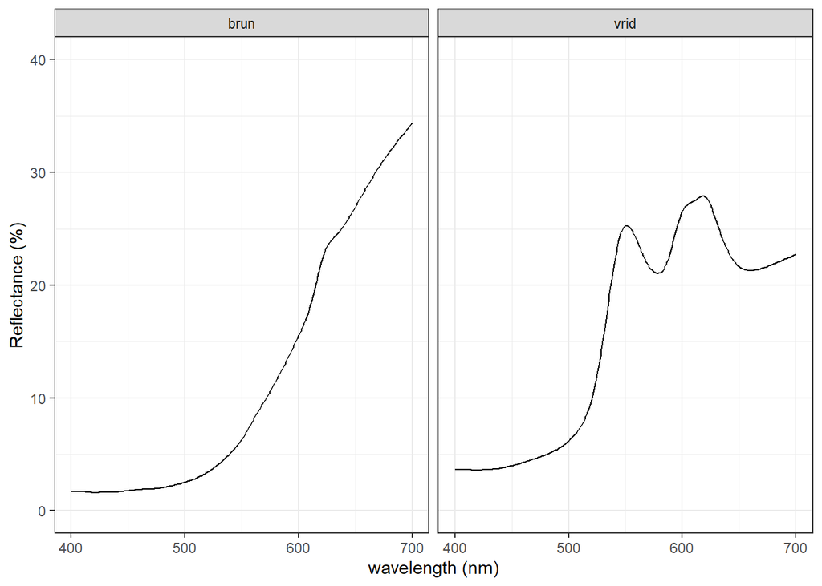

```r
Example1 <-
  sphmv %>%
  select (wl, brun, vrid) %>%  # select A. brunipenis and A. viriditarsis
  gather (key = spp, value = Reflectance, - wl) # prepare for ggplot

ggplot(data = Example1, aes(x = wl, y = Reflectance, group = spp ))+
  geom_line()+
  theme_bw()+
  facet_wrap(~ spp)+
  ylim(0, 40) +
  ylab("Reflectance (%)")+
  xlab("wavelength (nm)")
```

Directional reflectance

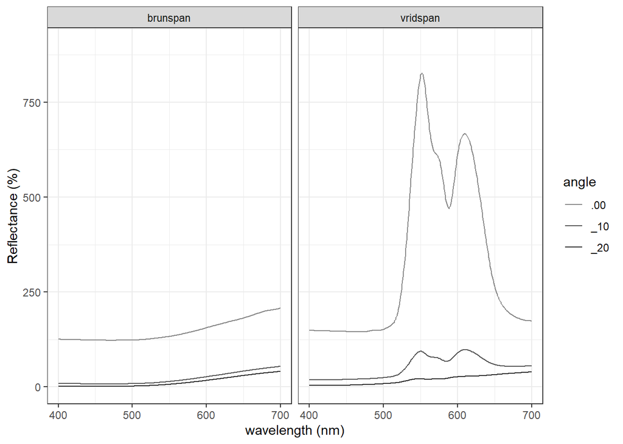

```r
Example2<-
  FixSpan %>% # from the fixed span set (specularity)
  select (wl, contains("brun")| # select A. brunipenis
              contains("vrid")) %>%  # And A. viriditarsis
  gather (key = spp_angle, value = Reflectance, - wl) %>%  # prepare for ggplot
  separate (spp_angle,sep=8,c("spp","angle")) %>% # ssp and angle into 2 columns
  filter (angle == ".00"| # bisector at 0 - Normal
          angle == "_10"| # bisector at -10
          angle == "_20") # bisector at -20

ggplot(data = Example2, aes(x = wl, y = Reflectance, colour = angle ))+
  geom_line()+
  scale_colour_manual(values=c("gray52","gray32","gray16",
                               "gray52","gray32","gray16"))+
  theme_bw()+
  facet_wrap(~ spp)+
  ylim(0, 900) +
  ylab("Reflectance (%)")+
  xlab("wavelength (nm)")
```

## Fig 3. Diversity in VIS

The examples show different magnitudes of iridescence ( *A. aureus* and *C. frenchii* ), reverse iridescence (red shift in *A. laetus*) and no iridescence ( *A. prasinus*).

Hemispherical reflectance

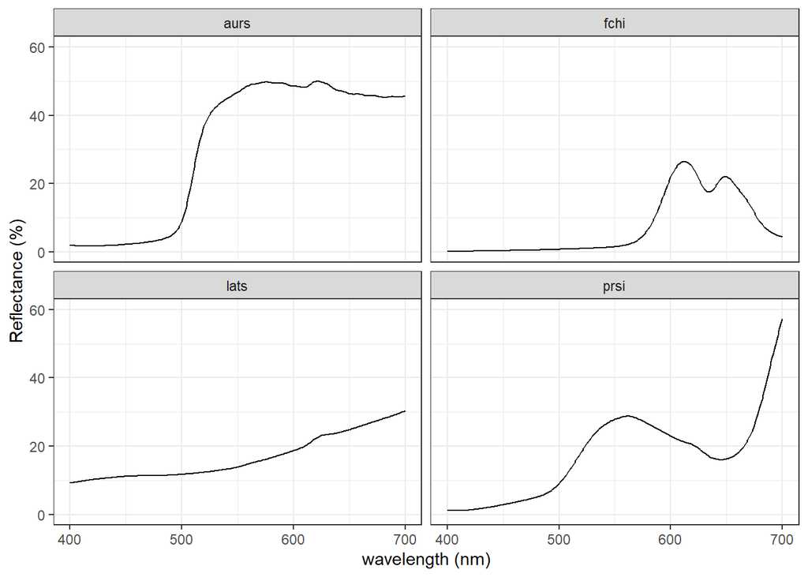

```r
Example3 <-
  sphmv %>%
  select (wl, aurs, fchi, lats, prsi) %>%  # select species
  gather (key = spp, value = Reflectance, - wl) # prepare for ggplot

ggplot(data = Example3, aes(x = wl, y = Reflectance, group = spp ))+
  geom_line()+
  theme_bw()+
  facet_wrap(~ spp)+
  ylim(0, 60) +
  ylab("Reflectance (%)")+
  xlab("wavelength (nm)")
```

Directional reflectance - Iridescence

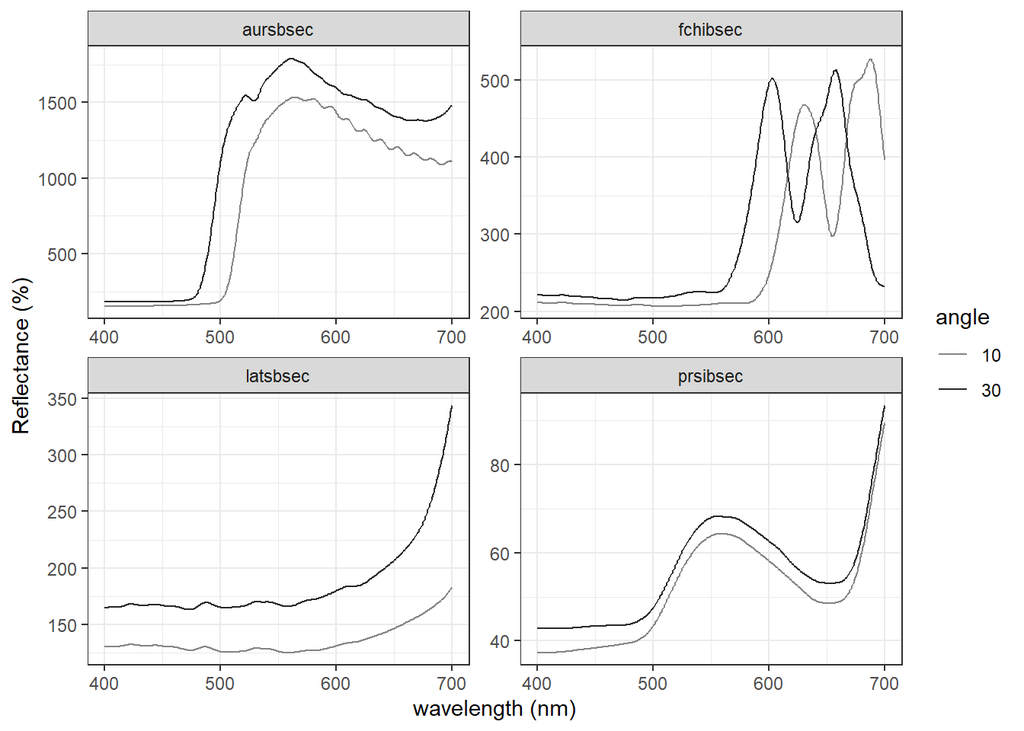

```r
Example4<-
  FixBsec %>% # from the fixed bisector set
  select (wl, contains("aurs")| # A. aureus
              contains("fchi")| # C. frenchi
              contains("lats")| # A. laetus
              contains("prsi")  # A. prasinus
          ) %>%  # select species
  gather (key = spp_angle, value = Reflectance, - wl) %>%  # prepare for ggplot
  separate (spp_angle,sep=8,c("spp","angle")) %>% # ssp and angle into 2 columns
  filter (angle == "10"| # span 10 deg
          angle == "30") # span 30 deg

ggplot(data = Example4, aes(x = wl, y = Reflectance, colour = angle ))+
  geom_line()+
  scale_colour_manual(values=rep(c("gray52","gray16"),8))+
  theme_bw()+
  facet_wrap(~ spp,  scales = "free")+
  ylab("Reflectance (%)")+
  xlab("wavelength (nm)")
```

Directional reflectance - Specularity

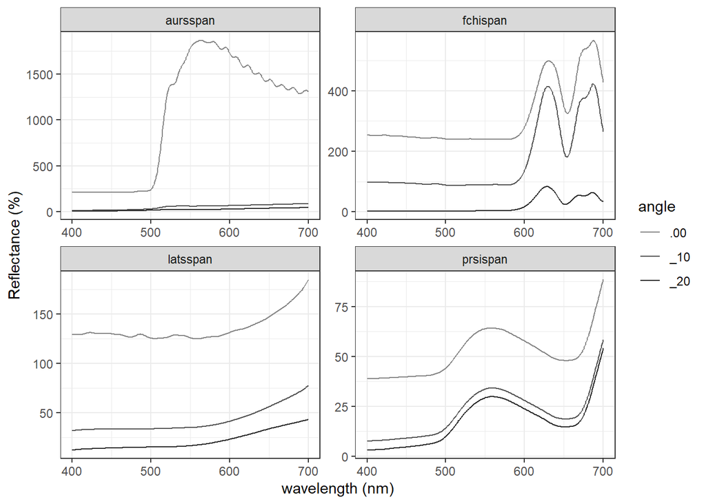

```r
Example5<-
  FixSpan %>% # from the fixed span set
  select (wl, contains("aurs")| # A. aureus
              contains("fchi")| # C. frenchi
              contains("lats")| # A. laetus
              contains("prsi")  # A. prasinus
          ) %>%  # select species
  gather (key = spp_angle, value = Reflectance, - wl) %>%  # prepare for ggplot
  separate (spp_angle,sep=8,c("spp","angle")) %>% # ssp and angle into 2 columns
  filter (angle == ".00"|  # bisector at 0 - Normal
          angle == "_10"|  # bisector at 10
          angle == "_20")  # bisector at 20

ggplot(data = Example5, aes(x = wl, y = Reflectance, colour = angle ))+
  geom_line()+
  scale_colour_manual(values=rep(c("gray52","gray32","gray16"),8))+
  theme_bw()+
  facet_wrap(~ spp,  scales = "free")+
  ylab("Reflectance (%)")+
  xlab("wavelength (nm)")
```

## Fig 4. Diversity in NIR

The examples show different magnitudes of NIR iridescence and NIR specularity

Hemispherical reflectance

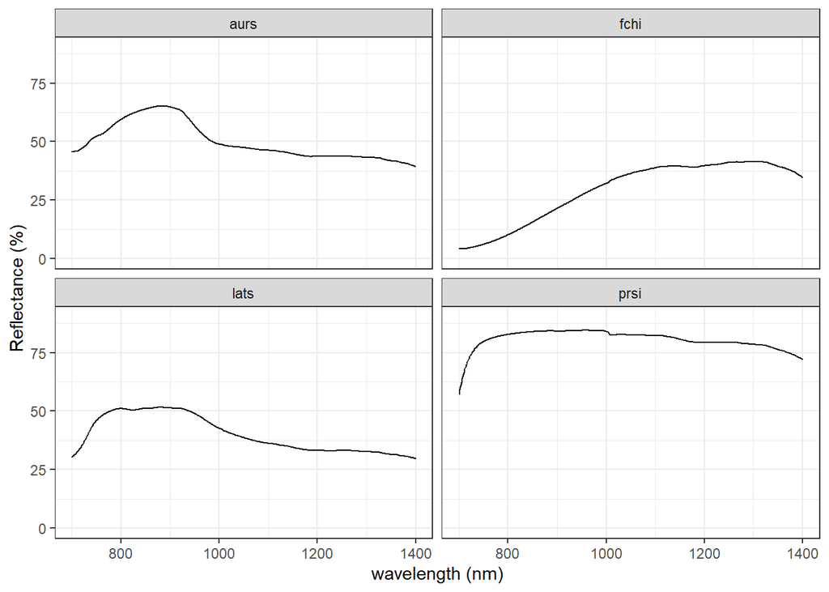

```r
Example6 <-
  sphir %>%
  select (wl, aurs, fchi, lats, prsi) %>%  # select species
  gather (key = spp, value = Reflectance, - wl) # prepare for ggplot

ggplot(data = Example6, aes(x = wl, y = Reflectance, group = spp ))+
  geom_line()+
  theme_bw()+
  facet_wrap(~ spp)+
  ylim(0, 90) +
  ylab("Reflectance (%)")+
  xlab("wavelength (nm)")
```

Directional reflectance - Iridescence

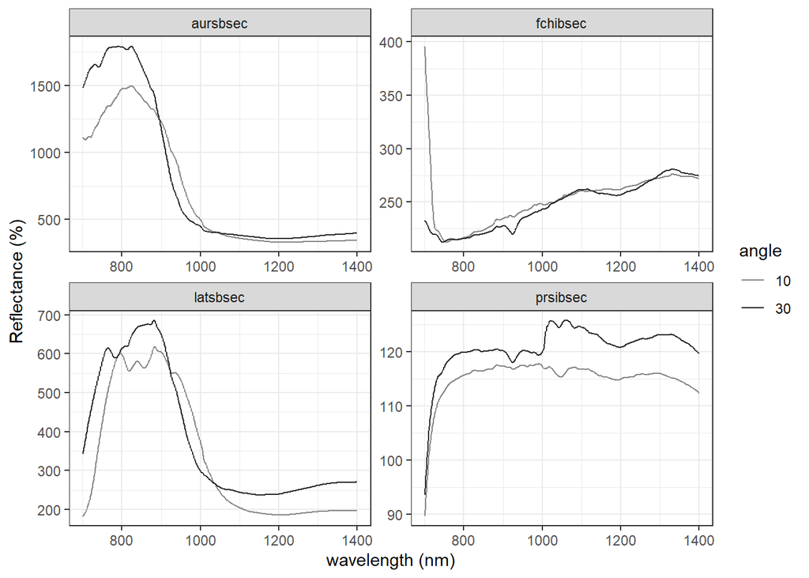

```r
Example7<-
  FixBsecN %>% # from the fixed bisector set
  select (wl, contains("aurs")| # A. aureus
              contains("fchi")| # C. frenchi
              contains("lats")| # A. laetus
              contains("prsi")  # A. prasinus
          ) %>%  # select species
  gather (key = spp_angle, value = Reflectance, - wl) %>%  # prepare for ggplot
  separate (spp_angle,sep=8,c("spp","angle")) %>% # ssp and angle into 2 columns
  filter (angle == "10"| # span 10 deg
          angle == "30") # span 30 deg

ggplot(data = Example7, aes(x = wl, y = Reflectance, colour = angle ))+
  geom_line()+
  scale_colour_manual(values=rep(c("gray52","gray16"),8))+
  theme_bw()+
  facet_wrap(~ spp,  scales = "free")+
  ylab("Reflectance (%)")+
  xlab("wavelength (nm)")
```

Directional reflectance - Specularity

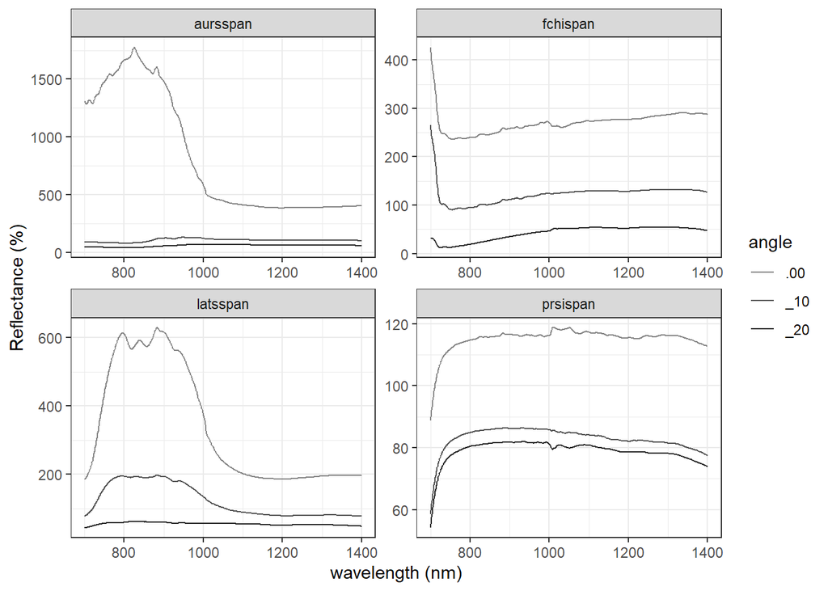

```r
Example8<-
  FixSpanN %>% # from the fixed span set
  select (wl, contains("aurs")| # A. aureus
              contains("fchi")| # C. frenchi
              contains("lats")| # A. laetus
              contains("prsi")  # A. prasinus
          ) %>%  # select species
  gather (key = spp_angle, value = Reflectance, - wl) %>%  # prepare for ggplot
  separate (spp_angle,sep=8,c("spp","angle")) %>% # ssp and angle into 2 columns
  filter (angle == ".00"|  # bisector at 0 - Normal
          angle == "_10"|  # bisector at 10
          angle == "_20")  # bisector at 20

ggplot(data = Example8, aes(x = wl, y = Reflectance, colour = angle ))+
  geom_line()+
  scale_colour_manual(values=rep(c("gray52","gray32","gray16"),8))+
  theme_bw()+
  facet_wrap(~ spp,  scales = "free")+
  ylab("Reflectance (%)")+
  xlab("wavelength (nm)")
```

# Table 3 - Correlations

```r
# Visible

# use VISParameters produced in the section VIS Parameters

VIS_var <- VISParameters[,c(2:9)] # remove the categorical variables

VIS_mat <- Hmisc::rcorr(as.matrix(VIS_var))
VisR2 <- round(VIS_mat$r, 2) # R2 values
VisCp <- round(VIS_mat$P, 3) # p  values

VisR2 %>%
  kbl() %>%
  kable_paper("hover", full_width = F)
```

|  | NumPeaks | SpecLocation | PeakWidth | TotLightRefl | SpectralPurity | BlueShift | Specularity | MaxRefl |
| --- | --- | --- | --- | --- | --- | --- | --- | --- |
| NumPeaks | 1.00 | -0.34 | 0.37 | -0.39 | 0.60 | 0.58 | 0.37 | 0.20 |
| SpecLocation | -0.34 | 1.00 | -0.32 | 0.09 | -0.71 | -0.16 | -0.13 | -0.16 |
| PeakWidth | 0.37 | -0.32 | 1.00 | 0.07 | 0.54 | 0.19 | 0.10 | 0.45 |
| TotLightRefl | -0.39 | 0.09 | 0.07 | 1.00 | -0.27 | -0.24 | -0.26 | 0.25 |
| SpectralPurity | 0.60 | -0.71 | 0.54 | -0.27 | 1.00 | 0.47 | 0.28 | 0.32 |
| BlueShift | 0.58 | -0.16 | 0.19 | -0.24 | 0.47 | 1.00 | 0.36 | 0.22 |
| Specularity | 0.37 | -0.13 | 0.10 | -0.26 | 0.28 | 0.36 | 1.00 | 0.62 |
| MaxRefl | 0.20 | -0.16 | 0.45 | 0.25 | 0.32 | 0.22 | 0.62 | 1.00 |

```r
VisCp %>%
  kbl() %>%
  kable_paper("hover", full_width = F)
```

|  | NumPeaks | SpecLocation | PeakWidth | TotLightRefl | SpectralPurity | BlueShift | Specularity | MaxRefl |
| --- | --- | --- | --- | --- | --- | --- | --- | --- |
| NumPeaks | NA | 0.049 | 0.030 | 0.021 | 0.000 | 0.000 | 0.031 | 0.256 |
| SpecLocation | 0.049 | NA | 0.058 | 0.612 | 0.000 | 0.355 | 0.445 | 0.371 |
| PeakWidth | 0.030 | 0.058 | NA | 0.671 | 0.001 | 0.268 | 0.554 | 0.006 |
| TotLightRefl | 0.021 | 0.612 | 0.671 | NA | 0.122 | 0.161 | 0.131 | 0.144 |
| SpectralPurity | 0.000 | 0.000 | 0.001 | 0.122 | NA | 0.004 | 0.109 | 0.057 |
| BlueShift | 0.000 | 0.355 | 0.268 | 0.161 | 0.004 | NA | 0.032 | 0.205 |
| Specularity | 0.031 | 0.445 | 0.554 | 0.131 | 0.109 | 0.032 | NA | 0.000 |
| MaxRefl | 0.256 | 0.371 | 0.006 | 0.144 | 0.057 | 0.205 | 0.000 | NA |

```r
# NIR

# use NIRParameters produced in the section NIR Parameters

NIR_var <- NIRParameters[,c(2:9)] #remove the categorical variables

NIR_mat <- Hmisc::rcorr(as.matrix(NIR_var))
NIRR2 <- round(NIR_mat$r, 3) # R2 values
NIRCp <- round(NIR_mat$P, 3) # p  values

NIRR2 %>%
  kbl() %>%
  kable_paper("hover", full_width = F)
```

|  | NumPeaks | SpecLocation | TotLightRefl | Ratio | Spectral.Purity | BlueShift | Specularity | MaxRefl |
| --- | --- | --- | --- | --- | --- | --- | --- | --- |
| NumPeaks | 1.000 | -0.469 | 0.088 | -0.273 | 0.535 | 0.541 | 0.306 | 0.579 |
| SpecLocation | -0.469 | 1.000 | -0.706 | 0.510 | -0.773 | -0.283 | 0.351 | -0.051 |
| TotLightRefl | 0.088 | -0.706 | 1.000 | -0.362 | 0.466 | 0.088 | -0.430 | -0.108 |
| Ratio | -0.273 | 0.510 | -0.362 | 1.000 | -0.096 | -0.360 | 0.082 | -0.102 |
| Spectral.Purity | 0.535 | -0.773 | 0.466 | -0.096 | 1.000 | 0.329 | -0.128 | 0.136 |
| BlueShift | 0.541 | -0.283 | 0.088 | -0.360 | 0.329 | 1.000 | 0.113 | 0.248 |
| Specularity | 0.306 | 0.351 | -0.430 | 0.082 | -0.128 | 0.113 | 1.000 | 0.820 |
| MaxRefl | 0.579 | -0.051 | -0.108 | -0.102 | 0.136 | 0.248 | 0.820 | 1.000 |

```r
NIRCp %>%
  kbl() %>%
  kable_paper("hover", full_width = F)
```

|  | NumPeaks | SpecLocation | TotLightRefl | Ratio | Spectral.Purity | BlueShift | Specularity | MaxRefl |
| --- | --- | --- | --- | --- | --- | --- | --- | --- |
| NumPeaks | NA | 0.005 | 0.614 | 0.112 | 0.001 | 0.001 | 0.074 | 0.000 |
| SpecLocation | 0.005 | NA | 0.000 | 0.002 | 0.000 | 0.100 | 0.039 | 0.769 |
| TotLightRefl | 0.614 | 0.000 | NA | 0.033 | 0.005 | 0.615 | 0.010 | 0.538 |
| Ratio | 0.112 | 0.002 | 0.033 | NA | 0.582 | 0.034 | 0.641 | 0.559 |
| Spectral.Purity | 0.001 | 0.000 | 0.005 | 0.582 | NA | 0.053 | 0.464 | 0.436 |
| BlueShift | 0.001 | 0.100 | 0.615 | 0.034 | 0.053 | NA | 0.518 | 0.150 |
| Specularity | 0.074 | 0.039 | 0.010 | 0.641 | 0.464 | 0.518 | NA | 0.000 |
| MaxRefl | 0.000 | 0.769 | 0.538 | 0.559 | 0.436 | 0.150 | 0.000 | NA |

# PCAs

## VIS

Run PCA

```r
cord <- cor(VIS_var) # default: pearsons correlation coeficient
N <- dim(VIS_var)[1] # number of observations

cortest.bartlett(cord,n=N) # Are the variables correlated? Yes p < 0.05
```

```
## $chisq
## [1] 116.3235
##
## $p.value
## [1] 9.861197e-13
##
## $df
## [1] 28
```

```r
eigVal <- eigen(cord) # Extract eigen values
vectorev <- eigVal$vectors # vector with the eigen values

# See Scree plot in supplementary materials

# Extract components
compv <- prcomp(VIS_var, retx=TRUE, center=TRUE, scale. = TRUE) # components
load<-compv$rotation # Loadings matrix - see supplementary

# See importance of the components in supplementary materials
```

Plot

```r
# Extract PC axes for plotting
PCAvalues <- data.frame(Species = VISParameters$BeetleName,
                        compv$x, group = VISParameters$group)

# Extract loadings of the variables
PCAloadings <- data.frame(Variables = rownames(compv$rotation), compv$rotation)

# PC1 vs PC2
PCV1<-ggplot(PCAvalues, aes(x = PC1, y = PC2, colour = group)) +
  geom_point(size=5,alpha=0.3)+
  theme_bw()+
  geom_text(alpha=.3, size=3, aes(label=Species),col="black")+
  guides(color = "none", size = "none")+
  annotate("text", x = (PCAloadings$PC1[c(1,3,4,5,6,8)]*7),
           y = (PCAloadings$PC2[c(1,3,4,5,6,8)]*6.7),
           label = c( "Peaks",
                      "PeakWidth      ",
                      "TotLight",
                      "Purity",
                      "Blue shift              ",
                      "MaxDirectRefl"),cex=4)+
  geom_segment(data = (PCAloadings[c(1,3,4,5,6,8),]),
               aes(x = 0, y = 0, xend = (PC1*6),yend = (PC2*6)),
               arrow = arrow(length = unit(1/2, "picas")),
               color = "black") +
  xlim(-4.2,4.2)+
  geom_hline(yintercept = 0, linetype ="dashed",colour="gray")+
  geom_vline(xintercept = 0, linetype ="dashed",colour="gray")

# PC3 vs PC2
PCV2<-ggplot(PCAvalues, aes(x = PC3, y = PC2, colour = group)) +
  geom_point(size=5,alpha=0.3)+
  theme_bw()+
  geom_text(alpha=.3, size=3, aes(label=Species),col="black")+
  guides(color = "none", size = "none")+
  annotate("text", x = (PCAloadings$PC3[c(2,3,4,7,8)]*6.7),
           y = (PCAloadings$PC2[c(2,3,4,7,8)]*6.7),
           label = c("SpecLoc        ",
                     "PeakWidth",
                     "TotLight",
                     "        Specularity",
                     "MaxDirectRefl"),cex=4)+
  geom_segment(data = PCAloadings[c(2,3,4,7,8),],
               aes(x = 0, y = 0, xend = (PC3*6),
                   yend = (PC2*6)),
               arrow = arrow(length = unit(1/2, "picas")),
               color = "black") +
  xlim(-4.2,4.2)+
  geom_hline(yintercept = 0, linetype ="dashed",colour="gray")+
  geom_vline(xintercept = 0, linetype ="dashed",colour="gray")
```

## NIR

Run PCA

```r
cordi <- cor(NIR_var) # default: pearsons correlation coeficient
N <- dim(NIR_var)[1] # number of observations

cortest.bartlett(cordi, n = N) #Are the variables correlated? Yes
```

```
## $chisq
## [1] 178
##
## $p.value
## [1] 9.187824e-24
##
## $df
## [1] 28
```

```r
eigValnir <- eigen(cordi) #extract eigen values
vectorevn <- eigValnir$vectors # vector with eigen values

# See Scree plot at the end, for supplementary materials

#Extract components
compn <- prcomp(NIR_var, retx=TRUE, center=TRUE, scale. = TRUE) # components
lmatn <- compn$rotation # Loadings matrix -  see supplementary

# See importance of the components in supplementary materials
```

Plot

```r
# Extract PC axes for plotting
PCAvaluesn <- data.frame(Species=NIRParameters$BeetleName,
                         compn$x, group = NIRParameters$group)

# Extract loadings of the variables
PCAloadingsn <- data.frame(Variables = rownames(compn$rotation), compn$rotation)

# PC1 vs PC2
PCN1<-ggplot(PCAvaluesn, aes(x = PC1, y = PC2, colour = group)) +
  geom_point(size=5,alpha=0.3)+
  theme_bw()+
  geom_text(alpha=.3, size=3, aes(label=Species),col="black")+
  guides(color = "none", size = "none")+
  annotate("text", x = (PCAloadingsn$PC1*7.1), y = (PCAloadingsn$PC2*6.8),
           label = c("Peaks",
                     "SpecLoc",
                     "TotLight",
                     "Ratio       ",
                     "Purity ",
                     "                Blue shift",
                     "Specularity",
                     "MaxDirectRefl"),cex=4)+ # same as PCAloadingsn$Variables
  geom_segment(data = PCAloadingsn, aes(x = 0, y = 0, xend = (PC1*6),
                                        yend = (PC2*6)), arrow = arrow(
                                          length = unit(1/2, "picas")),
               color = "black") +
  xlim(-4.2,4.2)+
  geom_hline(yintercept = 0, linetype ="dashed",colour="gray")+
  geom_vline(xintercept = 0, linetype ="dashed",colour="gray")
```

## Fig. 5

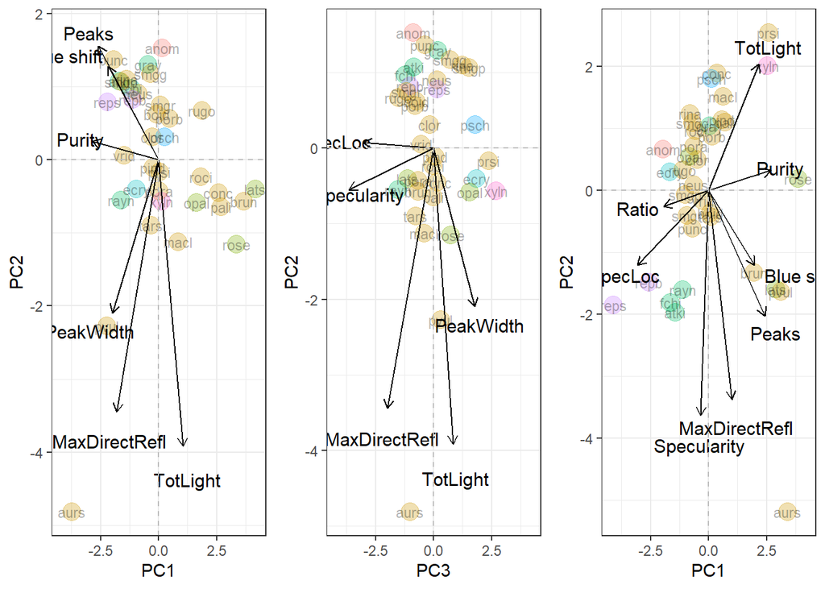

```r
grid.arrange(PCV1, PCV2, PCN1, nrow = 1)
```

# Supplementary

## Data sets

It is required to use the raw data, without averaging per repetition

We compared a subset of 7 species: *P. prasinus*, *C. frenchii*, *A. concolor*, *A. viriditarsis*, *A. aureus*, *A. laetus*, *A. prasinus*.

```r
# Hemispherical Reflectance Visible
 sph4R_V <-
   sphRawData %>% # Use raw data to compare replicates
   filter(wl >= 400 & wl <= 700) %>% # Limit range to visible wavelengths
   select(wl, contains("psch")|
              contains("fchi")|
              contains("conc")|
              contains("tars")|
              contains("aurs")|
              contains("lats")|
              contains("prsi")) %>% # only 7 spp
   procspec(.,opt="smooth",fixneg="zero",span=0.1)

# Hemispherical Reflectance NIR
 sph4R_N <-
   sphRawData %>% # Use raw data to compare replicates
   filter(wl >= 700 & wl <= 1400) %>%  # Limit range to NIR wavelengths
   select(wl, contains("psch")|
              contains("fchi")|
              contains("conc")|
              contains("tars")|
              contains("aurs")|
              contains("lats")|
              contains("prsi")) %>% # only 7 spp
   procspec(.,opt="smooth",fixneg="zero",span=0.1)

# Directional Reflectance - Fixed Bisector - VIS
 FixBsec4R <-
   dualRawData %>%
   filter(wl >= 400 & wl <= 700) %>% # visible range
   select(wl, contains("bsec")) %>%   # keep the bisector set only
   select(wl, contains("psch")|
              contains("fchi")|
              contains("conc")|
              contains("tars")|
              contains("aurs")|
              contains("lats")|
              contains("prsi")) # only 7 spp

# Directional Reflectance - Fixed Span - VIS
 FixSpan4R <-
   dualRawData %>%
   filter(wl >= 400 & wl <= 700) %>% # visible range
   select(wl, contains("span")) %>%  # keep the span set only
   select(wl, contains("psch")|
              contains("fchi")|
              contains("conc")|
              contains("tars")|
              contains("aurs")|
              contains("lats")|
              contains("prsi")) # only 7 spp
```

Preliminary Data Frames

```r
# Species Code
 SphSpp4Rep   <- substr(names(sph4R_V)[2 : length(names(sph4R_V))], 1, 4)
 FixBsecSpp4Rep  <- substr(names(FixBsec4R)[2 : length(names(FixBsec4R))], 1, 4)
 FixSpanSpp4Rep  <- substr(names(FixSpan4R)[2 : length(names(FixSpan4R))], 1, 4)

# Angles
 FixBsecAngles4R <-
   names(FixBsec4R)[2 : length(FixBsec4R)] %>%
   gsub("[[:lower:]]", "", .) %>%
   substr(.,1,2) %>%
   as.numeric()
 FixBsecAngles4R <- FixBsecAngles4R*2 # Since the notation referred to half span


 FixSpanAngles4R <-
   names(FixSpan4R)[2 : length(FixSpan4R)] %>%
   gsub("^.{8}", "", .) %>%  # remove the first 8 characters
   gsub(  "\\.", "", .) %>%  # remove the dot (meant positive angles)
   gsub(  "_", "-" , .) %>%  # replace _ with - (meant negative angles)
   gsub(  "r.*", "", .) %>%  # remove the replicate code r_
   as.numeric ()

# Preliminary data frame for FixBsec
 RepFixBsec <- data.frame ("BeetleName" = FixBsecSpp4Rep,
                           "Angle" = FixBsecAngles4R)


# Preliminary data frame for FixSpan
 RepFixSpan <- data.frame("BeetleName" = FixSpanSpp4Rep,
                          "Angle" = FixSpanAngles4R)
```

## Repeatability

We evaluated repeatability as the agreement of successive repetitions of the same measurement for spectral location and total light reflected in hemispherical reflectance measurements (VIS and NIR) and spectral location and mean reflectance in directional reflectance measurements.

We estimated repeatability using a bootstrapping tool for Gaussian data and posteriorly calculating the percentage of variance explained by the groups (repeatability estimate and its standard error) with p-values based on a likelihood ratio test (all results in “Consolidated”)

#### Hemispherical reflectance

##### Total Reflectance - VIS

```r
# Extract Total Light Reflectance
BaseTR4RVIS <- summary(sph4R_V) # obtain summary spectral parameters
TotRefl_VIS <- BaseTR4RVIS$B1 # a vector with the total reflectance

# Add to a data frame
Hemisph4R <- data.frame("Beetle" = SphSpp4Rep,
                        "TotRefl" = TotRefl_VIS)

# Test Repeatability
rpt1 <- rpt(TotRefl~ (1|Beetle),"Beetle", data = Hemisph4R,
          nboot = 1000, npermut = 0, datatype = "Gaussian")
```

```
## Bootstrap Progress:
```

##### Spectral Location - VIS

```r
# Extract Spectral Location

# We did not use the automated version
# But we applied the same correction to all replicates of the same spp
SLocVis4R<-as.numeric(c(
  # psch
  peakshape(sph4R_V[sph4R_V$wl <= 650, c(1, 2)])$H1-
  peakshape(sph4R_V[sph4R_V$wl <= 650, c(1, 2)])$HWHM.l, # replica 1

  peakshape(sph4R_V[sph4R_V$wl <= 650, c(1, 3)])$H1-
  peakshape(sph4R_V[sph4R_V$wl <= 650, c(1, 3)])$HWHM.l, # replica 2

  peakshape(sph4R_V[sph4R_V$wl <= 650, c(1, 4)])$H1-
  peakshape(sph4R_V[sph4R_V$wl <= 650, c(1, 4)])$HWHM.l, # replica 3

  peakshape(sph4R_V[sph4R_V$wl <= 650, c(1, 5)])$H1-
  peakshape(sph4R_V[sph4R_V$wl <= 650, c(1, 5)])$HWHM.l, # replica 4

  # fchi
  peakshape(sph4R_V[, c(1, 6)])$H1-
  peakshape(sph4R_V[, c(1, 6)])$HWHM.l, # replica 1

  peakshape(sph4R_V[, c(1, 7)])$H1-
  peakshape(sph4R_V[, c(1, 7)])$HWHM.l, # replica 2

  peakshape(sph4R_V[, c(1, 8)])$H1-
  peakshape(sph4R_V[, c(1, 8)])$HWHM.l, # replica 3

  peakshape(sph4R_V[, c(1, 9)])$H1-
  peakshape(sph4R_V[, c(1, 9)])$HWHM.l, # replica 4

  # conc
  peakshape(sph4R_V[, c(1, 10)])$H1-
  peakshape(sph4R_V[, c(1, 10)])$HWHM.l, # replica 1

  peakshape(sph4R_V[, c(1, 11)])$H1-
  peakshape(sph4R_V[, c(1, 11)])$HWHM.l, # replica 2

  peakshape(sph4R_V[, c(1, 12)])$H1-
  peakshape(sph4R_V[, c(1, 12)])$HWHM.l, # replica 3

  peakshape(sph4R_V[, c(1, 13)])$H1-
  peakshape(sph4R_V[, c(1, 13)])$HWHM.l, # replica 4

  # tars
  peakshape(sph4R_V[, c(1, 14)])$H1-
  peakshape(sph4R_V[, c(1, 14)])$HWHM.l, # replica 1

  peakshape(sph4R_V[, c(1, 15)])$H1-
  peakshape(sph4R_V[, c(1, 15)])$HWHM.l, # replica 2

  peakshape(sph4R_V[, c(1, 16)])$H1-
  peakshape(sph4R_V[, c(1, 16)])$HWHM.l, # replica 3

  peakshape(sph4R_V[, c(1, 17)])$H1-
  peakshape(sph4R_V[, c(1, 17)])$HWHM.l, # replica 4

  # aurs
  peakshape(sph4R_V[, c(1, 18)])$H1-
  peakshape(sph4R_V[, c(1, 18)])$HWHM.l, # replica 1

  peakshape(sph4R_V[, c(1, 19)])$H1-
  peakshape(sph4R_V[, c(1, 19)])$HWHM.l, # replica 2

  peakshape(sph4R_V[, c(1, 20)])$H1-
  peakshape(sph4R_V[, c(1, 20)])$HWHM.l, # replica 3

  peakshape(sph4R_V[, c(1, 21)])$H1-
  peakshape(sph4R_V[, c(1, 21)])$HWHM.l, # replica 4

  # lats
  peakshape(sph4R_V[, c(1, 22)])$H1-
  peakshape(sph4R_V[, c(1, 22)])$HWHM.l, # replica 1

  peakshape(sph4R_V[, c(1, 23)])$H1-
  peakshape(sph4R_V[, c(1, 23)])$HWHM.l, # replica 2

  peakshape(sph4R_V[, c(1, 24)])$H1-
  peakshape(sph4R_V[, c(1, 24)])$HWHM.l, # replica 3

  peakshape(sph4R_V[, c(1, 25)])$H1-
  peakshape(sph4R_V[, c(1, 25)])$HWHM.l, # replica 4

  # prsi
  peakshape(sph4R_V[sph4R_V$wl <= 650, c(1, 26)])$H1-
  peakshape(sph4R_V[sph4R_V$wl <= 650, c(1, 26)])$HWHM.l, # replica 1

  peakshape(sph4R_V[sph4R_V$wl <= 650, c(1, 27)])$H1-
  peakshape(sph4R_V[sph4R_V$wl <= 650, c(1, 27)])$HWHM.l, # replica 2

  peakshape(sph4R_V[sph4R_V$wl <= 650, c(1, 28)])$H1-
  peakshape(sph4R_V[sph4R_V$wl <= 650, c(1, 28)])$HWHM.l, # replica 3

  peakshape(sph4R_V[sph4R_V$wl <= 650, c(1, 29)])$H1-
  peakshape(sph4R_V[sph4R_V$wl <= 650, c(1, 29)])$HWHM.l # replica 4

))
```

```r
# Add to the data frame
Hemisph4R$SpecLoc <- SLocVis4R

# Test Repeatability
rpt2 <- rpt(SpecLoc~ (1|Beetle),"Beetle", data = Hemisph4R,
          nboot = 1000, npermut = 0, datatype = "Gaussian")
```

##### Total Reflectance - NIR

```r
# Extract Total Light Reflectance
BaseTR4RNIR <- summary(sph4R_N) # obtain summary spectral parameters
TotRefl_NIR <- BaseTR4RNIR$B1 # a vector with the total reflectance

# Add to the data frame
Hemisph4R$TotReflNIR <- TotRefl_NIR

# Test Repeatability
rpt3 <- rpt(TotReflNIR~ (1|Beetle), "Beetle", data = Hemisph4R,
          nboot = 1000, npermut = 0, datatype = "Gaussian")
```

```
## Bootstrap Progress:
```

##### Spectral Location - NIR

```r
# After evaluating each of these manually, we decided a correction was needed
# Wavelength was limited to < 1000 for all spectra
sph4R_NLess100<-
  sph4R_N %>%
  filter(wl <= 1000) # to avoid artifacts

# Find spectral location
BaseSLocNIR <- peakshape(sph4R_NLess100) # obtain peakshape
```

```r
SLocNIR4R <- BaseSLocNIR$H1 - BaseSLocNIR$HWHM.l # Obtain Spectral location

# Add to the data frame
Hemisph4R$SpecLocNIR <- SLocNIR4R

# Test repeatability
rpt4 <- rpt(SpecLocNIR~ (1|Beetle),"Beetle", data = Hemisph4R,
          nboot = 1000, npermut = 0, datatype = "Gaussian")
```

#### Directional reflectance

##### Spectral Location - VIS

```r
# Extract the spectral location - Automated

# Apply automated formula
SpLc_4R<- peakshape(FixBsec4R) # obtain peakshape
```

```r
SpecLoc_4R <- SpLc_4R$H1 - SpLc_4R$HWHM.l # Obtain Spectral location

# Add to data frame
RepFixBsec$SpecLoc <- SpecLoc_4R

# Apply corrections

## Subset the species that need correction (according to manual evaluation)
CorrectSpecLoc_4R<-
  FixBsec4R %>%
  select(wl, contains("fchi")|
             contains("prsi")|
             contains("xyln")|
             contains("smgg")|
             contains("psch")) %>%
  filter(wl < 630) # Limit the spectral range

## Apply automated formula to the subset
SpLc_4R_sub<- peakshape(CorrectSpecLoc_4R) # obtain peakshape
```

```r
SpecLoc_4R_sub <- SpLc_4R_sub$H1 - SpLc_4R_sub$HWHM.l # Obtain Spectral location

## create a preliminary data frame
Special.cases4R <-
  RepFixBsec %>%
  filter (BeetleName == "fchi"|
          BeetleName == "prsi"|
          BeetleName == "xyln"|
          BeetleName == "smgg"|
          BeetleName == "psch")

## Replace the spectral location column in the preliminary data frame
Special.cases4R$SpecLoc <- SpecLoc_4R_sub

## Apply corrections to the data frame
RepFixBsec <-
  RepFixBsec %>%
  filter(BeetleName != "fchi"&
         BeetleName != "prsi"&
         BeetleName != "xyln"&
         BeetleName != "smgg"&
         BeetleName != "psch") %>% # remove the species that need correction
  bind_rows(Special.cases4R) %>% # add the special cases (corrected)
  mutate(Beet_Geom = # because reflectance varies with the combination
         paste(BeetleName, Angle, sep = '_')) # new column spp_angle

# Test Repeatability

rpt5 <- rpt(SpecLoc~ (1|Beet_Geom),"Beet_Geom", data=RepFixBsec,
          nboot = 1000, npermut=0, datatype="Gaussian")
```

##### Mean Reflectance - VIS

```r
# Extract Total Light Reflectance
BaseTR4Rspan <- summary(FixSpan4R) # obtain summary spectral parameters
MeanRefl_span <- BaseTR4Rspan$B2 # a vector with the mean reflectance

# Add to data frame
RepFixSpan <- data.frame("BeetleName" = FixSpanSpp4Rep,
                          "Angle" = FixSpanAngles4R,
                          "MeanRefl" = MeanRefl_span)

# Create a concatenated column spp_angle
RepFixSpan <-
  RepFixSpan %>%
  mutate(Beet_Geom = # because reflectance varies with the combination
         paste(BeetleName, Angle, sep = '_')) # new column spp_angle


# Test Repeatability
rpt6 <- rpt(MeanRefl ~ (1|Beet_Geom),"Beet_Geom", data=RepFixSpan,
          nboot = 1000, npermut=0, datatype="Gaussian")
```

```
## Bootstrap Progress:
```

#### Consolidated

We produced a matrix with the repeatability index and standard deviation around the estimate of repeatability for each parameter evaluated.

The row “groups” refers to the number of species studied in the hemispherical reflectance data. And it refers to the species_angle combinations studied on each of the directional reflectance sets:

Fixed bisector - `DirectSpecLocVIS`: 7 species in 5 different geometries Fixed span - `DirectMeanReflVIS`: 7 species in 7 different geometries

The number of observations considers the number of groups * the replicates per group. In the hemispherical reflectance set we considered 4 replicates per group and in the directional reflectance set we considered 3 replicates per group.

##### Table S2

```r
SumData <- c (
  summary(rpt1)$R, summary(rpt2)$R, summary(rpt3)$R,
  summary(rpt4)$R, summary(rpt5)$R, summary(rpt6)$R,
  summary(rpt1)$se, summary(rpt2)$se, summary(rpt3)$se,
  summary(rpt4)$se, summary(rpt5)$se, summary(rpt6)$se)

SumData <-
  SumData %>%
  as.numeric() %>%
  round(.,3)

pvaluesRep<-c(
  summary(rpt1)$LRT[[2]][["LRT_P"]], summary(rpt2)$LRT[[2]][["LRT_P"]],
  summary(rpt3)$LRT[[2]][["LRT_P"]], summary(rpt4)$LRT[[2]][["LRT_P"]],
  summary(rpt5)$LRT[[2]][["LRT_P"]], summary(rpt6)$LRT[[2]][["LRT_P"]])

pvaluesRep <- formatC(pvaluesRep, format = "e", digits = 2)

NumObs<- as.numeric(c(
  summary(rpt1)$ngroups, summary(rpt2)$ngroups, summary(rpt3)$ngroups,
  summary(rpt4)$ngroups, summary(rpt5)$ngroups, summary(rpt6)$ngroups,
  summary(rpt1)$nobs, summary(rpt2)$nobs, summary(rpt3)$nobs,
  summary(rpt4)$nobs, summary(rpt5)$nobs, summary(rpt6)$nobs))

matrixdata<- c (SumData, pvaluesRep, NumObs)


rnames = c("Repeatability", "se.Repeatability", "p-value", "Groups", "Observations")
cnames = c("HemisphSpecLoc_VIS","HemisphTotRefl_VIS","HemisphSpecLoc_NIR",
           "HemisphTotRefl_NIR", "DirectSpecLocVIS", "DirectMeanReflVIS")

RepeatMatrix <- matrix(matrixdata, nrow = 5, ncol = 6,
                       byrow = TRUE,dimnames=list(rnames,cnames))

RepeatMatrix %>%
  kbl() %>%
  kable_paper("hover", full_width = F)
```

|  | HemisphSpecLoc_VIS | HemisphTotRefl_VIS | HemisphSpecLoc_NIR | HemisphTotRefl_NIR | DirectSpecLocVIS | DirectMeanReflVIS |
| --- | --- | --- | --- | --- | --- | --- |
| Repeatability | 0.825 | 0.977 | 0.905 | 0.983 | 0.998 | 0.92 |
| se.Repeatability | 0.141 | 0.029 | 0.085 | 0.023 | 0.001 | 0.019 |
| p-value | 2.44e-07 | 2.10e-16 | 5.10e-10 | 8.04e-18 | 1.19e-87 | 1.29e-44 |
| Groups | 7 | 7 | 7 | 7 | 35 | 49 |
| Observations | 28 | 28 | 28 | 28 | 105 | 147 |

All the repeatability values are high, most of them above 0.9

## Variability

Statistical descriptors mean and standard deviation were obtained for two of the main parameters: total reflectance and spectral location in hemispherical reflectance. Spectral location and mean reflectance in directional reflectance, in the fixed bisector and fixed span sets respectively.

#### Hemispherical reflectance

##### Total Reflectance - VIS

```r
VarHTotRefl_VIS <-
  Hemisph4R %>% # Parameters from the previous section
  select(Beetle, TotRefl) %>% # keep only the total reflectance
  group_by(Beetle) %>%  # group the replicates per species
  summarise(MeanTR = mean(TotRefl), # find mean
            sdTR = sd(TotRefl)) %>%  # find sd
  mutate(CV = sdTR / MeanTR *100 ) # coefficient of variation
```

##### Spectral Location - VIS

```r
VarHSpecLoc_VIS <-
  Hemisph4R %>% # Parameters from the previous section
  select(Beetle, SpecLoc) %>% # keep only spectral location
  group_by(Beetle) %>%  # group the replicates per species
  summarise(MeanSL = mean(SpecLoc), # find mean
            sdSL = sd(SpecLoc)) # find sd
```

##### Total Reflectance - NIR

```r
VarHTotRefl_NIR <-
  Hemisph4R %>% # Parameters from the previous section
  select(Beetle, TotReflNIR) %>% # keep only the total reflectance
  group_by(Beetle) %>%  # group the replicates per species
  summarise(MeanTRN = mean(TotReflNIR), # find mean
            sdTRN = sd(TotReflNIR)) %>%  # find sd
  mutate(CV = sdTRN / MeanTRN * 100 ) # coefficient of variation
```

##### Spectral Location - NIR

```r
VarHSpecLoc_NIR <-
  Hemisph4R %>% # Parameters from the previous section
  select(Beetle, SpecLocNIR) %>% # keep only spectral location
  group_by(Beetle) %>%  # group the replicates per species
  summarise(MeanSLN = mean(SpecLocNIR), # find mean
            sdSLN = sd(SpecLocNIR)) # find sd
```

#### Directional reflectance

##### Spectral Location - VIS

```r
VarBsecSpecLoc <-
  RepFixBsec %>%
  group_by(Beet_Geom) %>%  # group the replicates per species and angle
  summarise(MeanBsecSL = mean(SpecLoc), # find mean
            sdBsecSL = sd(SpecLoc))  # find sd
```

##### Mean Reflectance - VIS

```r
VarSpanMeanRefl <-
  RepFixSpan %>%
  group_by(Beet_Geom) %>%  # group the replicates per species and angle
  summarise(MeanSpanMR = mean(MeanRefl), # find mean
            sdSpanMR = sd(MeanRefl)) %>%  # find sd
  mutate (C.V. = sdSpanMR / MeanSpanMR * 100) %>% # coefficient of variation
  mutate (CV = round (C.V.,2))
```

#### Consolidated

We evaluated the variability between replicates: Variation in spectral location is the standard deviation `_sd` (nm). Variation in total reflectance is the coefficient of variation `_CV`, i.e. standard deviation normalized by the mean of the parameter (dimensionless quantity).

##### Table S3

```r
# Variability in hemispherical reflectance measurements

Variability_Hemisph <- data.frame(
  "Beetle" = VarHTotRefl_VIS$Beetle,
  "TotRefl_VIS_CV" = round(VarHTotRefl_VIS$CV, 3),
  "SpecLoc_VIS_sd" = round(VarHSpecLoc_VIS$sdSL, 3),
  "TotRefl_NIR_CV" = round(VarHTotRefl_NIR$CV, 3),
  "SpecLoc_NIR_sd" = round(VarHSpecLoc_NIR$sdSLN, 3))

Variability_Hemisph %>%
  kbl() %>%
  kable_paper("hover", full_width = F)
```

| Beetle | TotRefl_VIS_CV | SpecLoc_VIS_sd | TotRefl_NIR_CV | SpecLoc_NIR_sd |
| --- | --- | --- | --- | --- |
| aurs | 8.751 | 1.915 | 7.227 | 7.550 |
| conc | 7.823 | 2.872 | 7.127 | 1.732 |
| fchi | 25.007 | 3.873 | 11.234 | 1.732 |
| lats | 9.390 | 4.967 | 3.344 | 1.291 |
| prsi | 30.897 | 2.062 | 14.286 | 0.577 |
| psch | 5.322 | 13.889 | 8.479 | 6.218 |
| tars | 28.600 | 2.217 | 6.128 | 14.546 |

##### Table S4

Variation in spectral location is the standard deviation `sdBsecSL` (nm):

```r
# Variability in fixed bisector set

Variability_FixBsec <-
  VarBsecSpecLoc %>%
  select (Beet_Geom, sdBsecSL) %>%
  mutate (SD = round(sdBsecSL,2)) %>% # round to 3
  select (Beet_Geom, SD) %>% # keep only SD
  separate (Beet_Geom,sep=4,c("spp","angle")) %>%  # ssp_angle into 2 columns
  spread (key = angle, value = SD) # angles to columns for visualization

Variability_FixBsec %>%
  kbl() %>%
  kable_paper("hover", full_width = F)
```

| spp | _20 | _30 | _40 | _50 | _60 |
| --- | --- | --- | --- | --- | --- |
| aurs | 1.53 | 1.15 | 1.00 | 2.08 | 1.15 |
| conc | 2.52 | 2.52 | 6.56 | 8.54 | 4.16 |
| fchi | 0.00 | 0.00 | 0.58 | 0.58 | 0.58 |
| lats | 1.53 | 1.53 | 1.15 | 1.15 | 0.58 |
| prsi | 1.00 | 0.00 | 0.58 | 1.53 | 1.53 |
| psch | 1.00 | 1.00 | 1.00 | 1.00 | 0.58 |
| tars | 4.93 | 1.53 | 2.08 | 3.51 | 2.08 |

##### Table S5

Variation in total reflectance is the coefficient of variation `_CV`, i.e. standard deviation normalized by the mean of the parameter (dimensionless quantity):

```r
# Variability in fixed span set

Variability_FixSpan <-
  VarSpanMeanRefl %>%
  separate (Beet_Geom,sep=5,c("spp","angle")) %>% # ssp and angle into 2 columns
  mutate (Spp = substr(spp,1,4)) %>%  # remove the _
  select (Spp, angle, CV) %>% # order columns
  arrange (Spp, angle) %>% # alphabetical and ascending order
  spread (key = angle, value = CV) # angles to columns for visualization

Variability_FixSpan %>%
  kbl() %>%
  kable_paper("hover", full_width = F)
```

| Spp | -10 | -20 | -30 | 0 | 10 | 20 | 30 |
| --- | --- | --- | --- | --- | --- | --- | --- |
| aurs | 7.92 | 62.42 | 14.67 | 29.78 | 28.06 | 7.43 | 6.82 |
| conc | 6.95 | 8.62 | 1.23 | 16.35 | 1.61 | 1.73 | 2.05 |
| fchi | 18.15 | 15.89 | 25.44 | 5.65 | 27.00 | 22.88 | 9.34 |
| lats | 11.43 | 1.75 | 1.58 | 3.25 | 7.40 | 8.65 | 0.87 |
| prsi | 1.64 | 2.26 | 4.00 | 4.27 | 5.98 | 8.51 | 16.65 |
| psch | 14.65 | 3.69 | 4.32 | 4.19 | 6.94 | 3.29 | 0.27 |
| tars | 21.74 | 7.56 | 1.80 | 3.89 | 5.99 | 4.56 | 1.05 |

## S6: Iridescence models

We compared the cosin model reported in Gruson et al 2019. with a linear model.

```r
IridModData <- read_csv("../Data/4.IridModelsData.csv")
# Keep only the spp where a Gaussian reression can be conducted
IridModDataCor <-
  IridModData %>%
  mutate (IS.NA = is.na(IridModData$a)) %>%
  filter (IS.NA == FALSE)

# Conduct a correlation test between b and d
# Consider the absolute value of d because that is the blueshift
cor.test (IridModDataCor$b, abs(IridModDataCor$d))
```

```
##
##  Pearson's product-moment correlation
##
## data:  x and y
## t = 12.24, df = 25, p-value = 4.696e-12
## alternative hypothesis: true correlation is not equal to 0
## 95 percent confidence interval:
##  0.8418920 0.9659391
## sample estimates:
##       cor
## 0.9257349
```

## PCA - VIS Details

### Fig. S3 A

Eigen Values

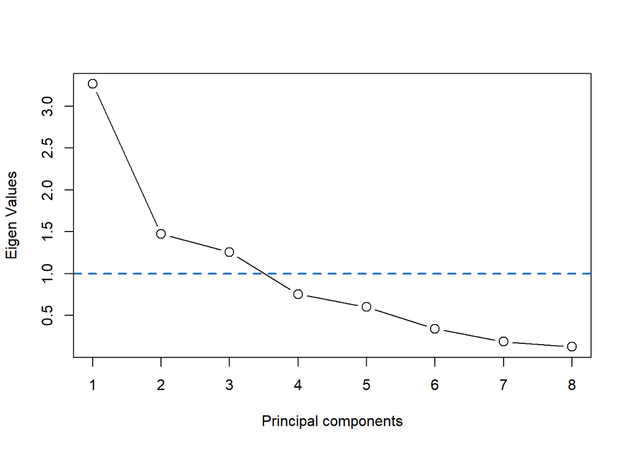

```r
{ plot(c(1:length(eigVal$values)),eigVal$values,type="b", cex=1.4,
     ylab="Eigen Values",xlab="Principal components")
abline(h=1,col="dodgerblue3",lwd=2,lty=2)}
```

### Fig. S3 B

Loadings Matrix

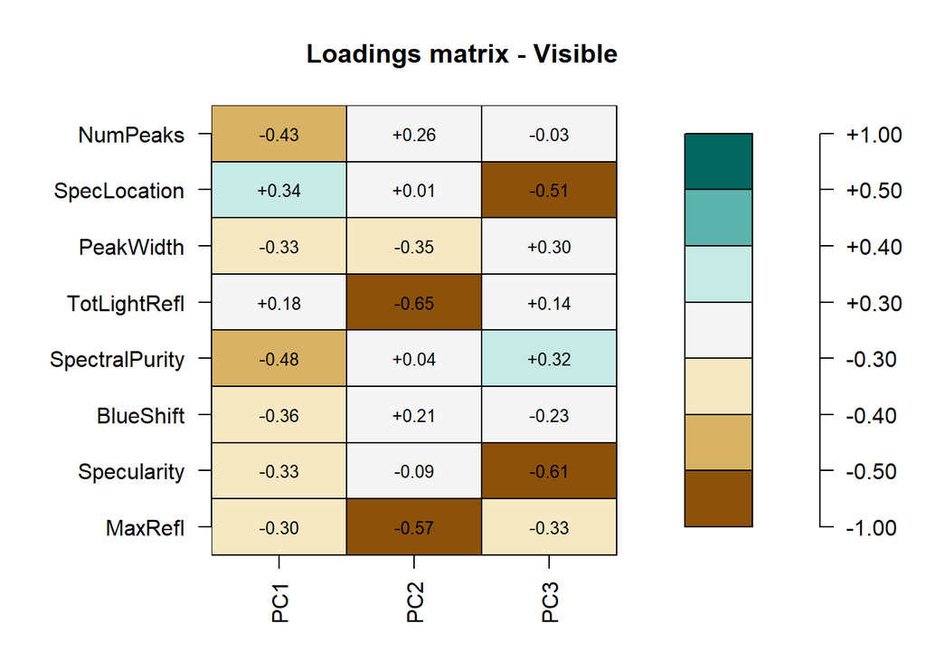

````r
# ```{r fig.align = "center", fig.height = "8cm", fig.width = "8cm", eval=FALSE}
par(mar=c(4, 8, 4, 4))
plot(load[,1:3],cex=0.8,breaks=c(-1,-0.5,-0.4,-0.3,0.3,0.4,0.5,1),
     las=2,ylab=" ",xlab=" ",
     digits=2,
     col=c("#8C510A" ,"#D8B365", "#F6E8C3",
           "#F5F5F5" ,"#C7EAE5" ,"#5AB4AC" ,"#01665E"),
     main="Loadings matrix - Visible              ")
````

### Table. S7

Importance of the components

```r
summary(compv)
```

```
## Importance of components:
##                           PC1    PC2    PC3     PC4     PC5     PC6     PC7
## Standard deviation     1.8065 1.2135 1.1198 0.86779 0.77599 0.58426 0.43212
## Proportion of Variance 0.4079 0.1841 0.1567 0.09413 0.07527 0.04267 0.02334
## Cumulative Proportion  0.4079 0.5920 0.7488 0.84288 0.91816 0.96083 0.98417
##                            PC8
## Standard deviation     0.35590
## Proportion of Variance 0.01583
## Cumulative Proportion  1.00000
```

## PCA - NIR Details

### Fig. S4 A

Eigen Values

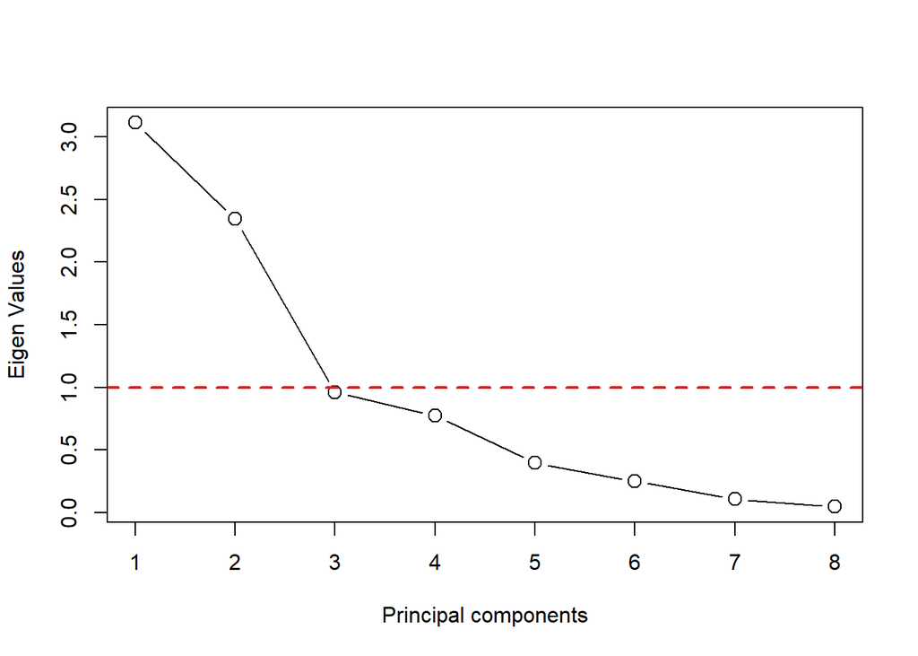

```r
{ plot(c(1:length(eigValnir$values)),eigValnir$values,type="b",cex=1.4,
     ylab="Eigen Values",xlab="Principal components")
abline(h=1,col="firebrick3",lwd=2,lty=2) }
```

### Fig. S4 B

Loadings Matrix

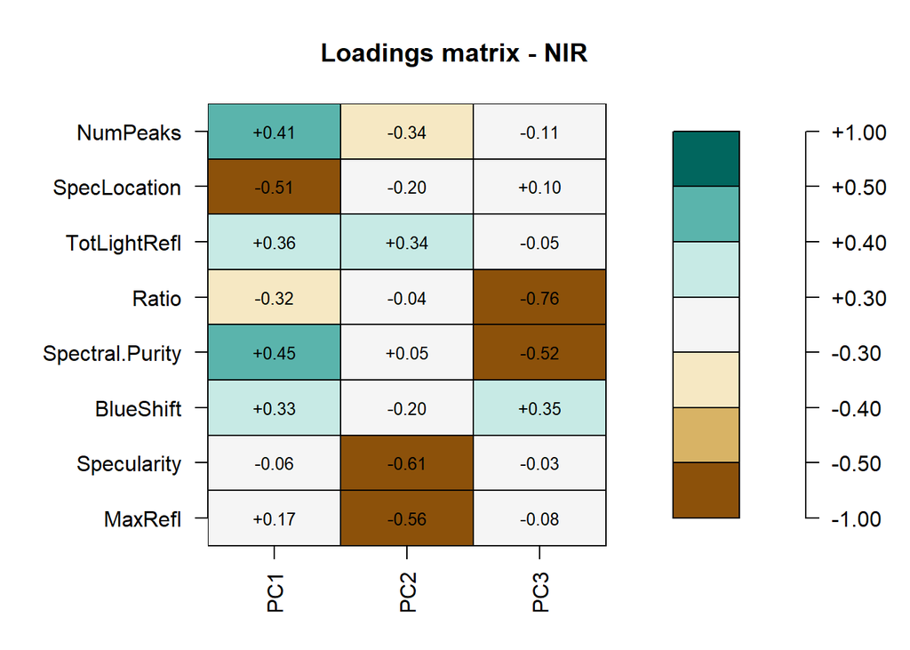

````r
# ```{r eval=FALSE, fig.align = "center", fig.height = "8cm", fig.width = "8cm"}
par(mar=c(4, 8, 4, 4))
plot(lmatn[,1:3],cex=0.8,breaks=c(-1,-0.5,-0.4,-0.3,0.3,0.4,0.5,1),
     las=2,ylab=" ",xlab=" ",
     digits=2,
     col=c("#8C510A" ,"#D8B365", "#F6E8C3",
           "#F5F5F5" ,"#C7EAE5" ,"#5AB4AC" ,"#01665E"),
     main="Loadings matrix - NIR              ")
````

### Table. S8

Importance of the components

```r
summary(compn)
```

```
## Importance of components:
##                          PC1    PC2    PC3     PC4     PC5     PC6     PC7
## Standard deviation     1.764 1.5314 0.9796 0.88008 0.63141 0.50172 0.33083
## Proportion of Variance 0.389 0.2932 0.1200 0.09682 0.04984 0.03147 0.01368
## Cumulative Proportion  0.389 0.6821 0.8021 0.89889 0.94873 0.98019 0.99387
##                            PC8
## Standard deviation     0.22139
## Proportion of Variance 0.00613
## Cumulative Proportion  1.00000
```